# Differential expression analysis for 2025-06 release JAX_RNAseq08

Bo Yu, Si Liu, Wei Sun

2025-08-14

Differential expression using the bulk RNAseq JAX_RNAseq08 data from the June 2025 release.

See bulk_RNAseq.xlsx for details of the dataset.

For PrS_day_6_nor_ASCL2_ELF5_NR2F2_nor, 20250327_GT25-RobsonP-14-run3, one of the two run_id values, has only one sample. The run_id covariate is ignored for the DE analysis.

## R libraries.

```r
library(ggplot2)
library(ggrepel)
library(ggpubr)
library(stringr)
library(MASS)
library(RColorBrewer)
library(DESeq2)
library(viridis)
library(ggpointdensity)
library(tidyverse)
library(data.table)
library(ComplexHeatmap)
library(UpSetR)
library(readxl)
library(ggsci)
library(ggprism)
theme_set(theme_classic())

path = "../../MorPhiC/data/MorPhiC_internal_releases/MorPhiC_Release_June_2025/JAX_RNAseq08/"
dat_path = file.path(path, "processed/Tables")
```

## Read in meta data

```r
meta = fread("data/June_2025/JAX_RNAseq08_meta_data.tsv", data.table = FALSE)
dim(meta)
```

```
## [1] 53 36
```

```r
meta[1:2, ]
```

```
##         clonal.label library_preparation.label                  label
## 1 MOK20046_72_80-WT1                GT24-08505 PrS-MOK20046_72_80-WT1
## 2 MOK20046_72_80-WT2                GT24-08506 PrS-MOK20046_72_80-WT2
##                                                                                     description
## 1 KOLF2.2J differentiated to the trophoblast lineage and favoring primitive syncytium formation
## 2 KOLF2.2J differentiated to the trophoblast lineage and favoring primitive syncytium formation
##                 differentiated_product_protocol_id model_system timepoint_value
## 1 dx.doi.org/10.17504/protocols.io.q26g7mwekgwz/v1          PrS               6
## 2 dx.doi.org/10.17504/protocols.io.q26g7mwekgwz/v1          PrS               6
##   timepoint_unit final_timepoint treatment_condition wt_control_status
## 1           days             yes      Not applicable                WT
## 2           days             yes      Not applicable                WT
##   ko_strategy ko_gene library_preparation.description
## 1          WT      WT                              NA
## 2          WT      WT                              NA
##   library_preparation.library_preparation_protocol_id
## 1    dx.doi.org/10.17504/protocols.io.3byl4z39ovo5/v1
## 2    dx.doi.org/10.17504/protocols.io.3byl4z39ovo5/v1
##   library_preparation.average_fragment_size
## 1                                       418
## 2                                       410
##   library_preparation.input_amount_value library_preparation.input_amount_unit
## 1                                    300                                    ng
## 2                                    300                                    ng
##   library_preparation.concentration_value
## 1                                    8.32
## 2                                   14.50
##   library_preparation.concentration_unit library_preparation.total_yield_value
## 1                                  ng/uL                                 166.4
## 2                                  ng/uL                                 290.0
##   library_preparation.total_yield_unit library_preparation.cdna_pcr_cycles
## 1                                   ng                                   0
## 2                                   ng                                   0
##   library_preparation.pcr_cycles_for_indexing
## 1                                          10
## 2                                          10
##                                          file_id                   run_id
## 1 WT_PrS_1_GT24-08505_AACGTTCC-AGTACTCC_S22_L006 20240909_GT24-RobsonP-19
## 2 WT_PrS_2_GT24-08506_GCAGAATT-TGGCCGGT_S38_L006 20240909_GT24-RobsonP-19
##   clonal.description clonal.parental_name clonal.clone_id clonal.type
## 1           KOLF2.2J             KOLF2.2J             WT1        iPSC
## 2           KOLF2.2J             KOLF2.2J             WT2        iPSC
##   clonal.zygosity clonal.cell_line_generation_protocol
## 1  Not applicable                       Not applicable
## 2  Not applicable                       Not applicable
##   clonal.treatment_condition clonal.wt_control_status
## 1             Not applicable                       WT
## 2             Not applicable                       WT
##   expression_alteration.label         model_organ
## 1              Not applicable primitive syncytium
## 2              Not applicable primitive syncytium
```

```r
names(meta)
```

```
##  [1] "clonal.label"
##  [2] "library_preparation.label"
##  [3] "label"
##  [4] "description"
##  [5] "differentiated_product_protocol_id"
##  [6] "model_system"
##  [7] "timepoint_value"
##  [8] "timepoint_unit"
##  [9] "final_timepoint"
## [10] "treatment_condition"
## [11] "wt_control_status"
## [12] "ko_strategy"
## [13] "ko_gene"
## [14] "library_preparation.description"
## [15] "library_preparation.library_preparation_protocol_id"
```

[output cut: 21 more lines]

```r
names(meta)[apply(meta, 2, \(x) any(is.na(x)))]
```

```
## [1] "library_preparation.description"
```

```r
table(meta$clonal.label)
```

```
##
##      MOK20046_72_80-WT1      MOK20046_72_80-WT2           MOK20046P-C03
##                       1                       1                       1
##           MOK20046P-F02           MOK20046P-H01     MOK20062_101_98-WT1
##                       1                       1                       1
##     MOK20062_101_98-WT2     MOK20062_101_98-WT3           MOK20062P-A02
##                       1                       1                       1
##           MOK20062P-E02           MOK20062P-H02           MOK20072P-A12
##                       1                       1                       1
##           MOK20072P-B06           MOK20072P-C05           MOK20080P-B05
##                       1                       1                       1
##           MOK20080P-F06           MOK20080P-H04           MOK20098P-A01
##                       1                       1                       1
##           MOK20098P-B06           MOK20098P-D02           MOK20098P-E05
##                       2                       2                       1
##           MOK20101P-A04           MOK20101P-B06           MOK20101P-E01
##                       1                       2                       1
##           MOK20101P-H01 MOK20105_125_98_101-WT1 MOK20105_125_98_101-WT2
##                       2                       1                       1
## MOK20105_125_98_101-WT3        MOK20105_125-WT1        MOK20105_125-WT2
##                       1                       1                       1
##        MOK20105_125-WT3           MOK20105P-A04           MOK20105P-A05
##                       1                       2                       2
##           MOK20105P-A06            MOK20108-WT1            MOK20108-WT2
##                       2                       1                       1
##            MOK20108-WT3           MOK20108P-A02           MOK20108P-C04
##                       1                       1                       1
##           MOK20108P-D05           MOK20125P-C07           MOK20125P-C10
##                       1                       2                       2
##           MOK20125P-G12
##                       2
```

```r
table(table(meta$clonal.label))
```

```
##
##  1  2
## 33 10
```

```r
table(table(meta$label))
```

```
##
##  1
## 53
```

```r
meta$timepoint = as.factor(meta$timepoint_value)
```

### Extract condition information

```r
unique(meta$label)
```

```
##  [1] "PrS-MOK20046_72_80-WT1"          "PrS-MOK20046_72_80-WT2"
##  [3] "PrS-MOK20046P-C03"               "PrS-MOK20046P-F02"
##  [5] "PrS-MOK20046P-H01"               "PrS-MOK20062_101_98-WT1-nor"
##  [7] "PrS-MOK20062_101_98-WT2-nor"     "PrS-MOK20062_101_98-WT3-nor"
##  [9] "PrS-MOK20062P-A02"               "PrS-MOK20062P-E02"
## [11] "PrS-MOK20062P-H02"               "PrS-MOK20072P-A12"
## [13] "PrS-MOK20072P-B06"               "PrS-MOK20072P-C05"
## [15] "PrS-MOK20080P-B05"               "PrS-MOK20080P-F06"
## [17] "PrS-MOK20080P-H04"               "PrS-MOK20098P-A01-nor"
## [19] "PrS-MOK20098P-B06-nor"           "PrS-MOK20098P-B06-hyp"
## [21] "PrS-MOK20098P-D02-nor"           "PrS-MOK20098P-D02-hyp"
## [23] "PrS-MOK20098P-E05-hyp"           "PrS-MOK20101P-A04-hyp"
## [25] "PrS-MOK20101P-B06-hyp"           "PrS-MOK20101P-B06-nor"
## [27] "PrS-MOK20101P-E01-nor"           "PrS-MOK20101P-H01-nor"
## [29] "PrS-MOK20101P-H01-hyp"           "PrS-MOK20105_125_98_101-WT1-hyp"
## [31] "PrS-MOK20105_125_98_101-WT2-hyp" "PrS-MOK20105_125_98_101-WT3-hyp"
## [33] "PrS-MOK20105_125-WT1-nor"        "PrS-MOK20105_125-WT2-nor"
## [35] "PrS-MOK20105_125-WT3-nor"        "PrS-MOK20105P-A04-hyp"
## [37] "PrS-MOK20105P-A04-nor"           "PrS-MOK20105P-A05-hyp"
## [39] "PrS-MOK20105P-A05-nor"           "PrS-MOK20105P-A06-nor"
## [41] "PrS-MOK20105P-A06-hyp"           "ExM-MOK20108-WT1"
## [43] "ExM-MOK20108-WT2"                "ExM-MOK20108-WT3"
## [45] "ExM-MOK20108P-A02"               "ExM-MOK20108P-C04"
## [47] "ExM-MOK20108P-D05"               "PrS-MOK20125P-C07-nor"
## [49] "PrS-MOK20125P-C07-hyp"           "PrS-MOK20125P-C10-nor"
## [51] "PrS-MOK20125P-C10-hyp"           "PrS-MOK20125P-G12-hyp"
## [53] "PrS-MOK20125P-G12-nor"
```

```r
meta = meta |>
  mutate(condition = sapply(label, \(x) {
    x = strsplit(x, '-')[[1]]
    ifelse(length(x) == 4, x[4], 'nor')
  }))
table(meta$label, meta$condition)
```

```
##
##                                   hyp nor
##   ExM-MOK20108-WT1                  0   1
##   ExM-MOK20108-WT2                  0   1
##   ExM-MOK20108-WT3                  0   1
##   ExM-MOK20108P-A02                 0   1
##   ExM-MOK20108P-C04                 0   1
##   ExM-MOK20108P-D05                 0   1
##   PrS-MOK20046_72_80-WT1            0   1
##   PrS-MOK20046_72_80-WT2            0   1
##   PrS-MOK20046P-C03                 0   1
##   PrS-MOK20046P-F02                 0   1
##   PrS-MOK20046P-H01                 0   1
##   PrS-MOK20062_101_98-WT1-nor       0   1
##   PrS-MOK20062_101_98-WT2-nor       0   1
##   PrS-MOK20062_101_98-WT3-nor       0   1
##   PrS-MOK20062P-A02                 0   1
##   PrS-MOK20062P-E02                 0   1
##   PrS-MOK20062P-H02                 0   1
##   PrS-MOK20072P-A12                 0   1
##   PrS-MOK20072P-B06                 0   1
##   PrS-MOK20072P-C05                 0   1
##   PrS-MOK20080P-B05                 0   1
##   PrS-MOK20080P-F06                 0   1
##   PrS-MOK20080P-H04                 0   1
##   PrS-MOK20098P-A01-nor             0   1
##   PrS-MOK20098P-B06-hyp             1   0
##   PrS-MOK20098P-B06-nor             0   1
##   PrS-MOK20098P-D02-hyp             1   0
##   PrS-MOK20098P-D02-nor             0   1
##   PrS-MOK20098P-E05-hyp             1   0
##   PrS-MOK20101P-A04-hyp             1   0
##   PrS-MOK20101P-B06-hyp             1   0
##   PrS-MOK20101P-B06-nor             0   1
##   PrS-MOK20101P-E01-nor             0   1
##   PrS-MOK20101P-H01-hyp             1   0
##   PrS-MOK20101P-H01-nor             0   1
##   PrS-MOK20105_125_98_101-WT1-hyp   1   0
##   PrS-MOK20105_125_98_101-WT2-hyp   1   0
##   PrS-MOK20105_125_98_101-WT3-hyp   1   0
##   PrS-MOK20105_125-WT1-nor          0   1
##   PrS-MOK20105_125-WT2-nor          0   1
##   PrS-MOK20105_125-WT3-nor          0   1
##   PrS-MOK20105P-A04-hyp             1   0
##   PrS-MOK20105P-A04-nor             0   1
##   PrS-MOK20105P-A05-hyp             1   0
##   PrS-MOK20105P-A05-nor             0   1
##   PrS-MOK20105P-A06-hyp             1   0
##   PrS-MOK20105P-A06-nor             0   1
##   PrS-MOK20125P-C07-hyp             1   0
##   PrS-MOK20125P-C07-nor             0   1
##   PrS-MOK20125P-C10-hyp             1   0
##   PrS-MOK20125P-C10-nor             0   1
##   PrS-MOK20125P-G12-hyp             1   0
##   PrS-MOK20125P-G12-nor             0   1
```

### Add gene-condition group information

```r
unique(meta$clonal.description)
```

```
##  [1] "KOLF2.2J"
##  [2] "KOLF2.2J DLX3 null by insertion of a premature termination codon with frameshift (PTC+1)"
##  [3] "KOLF2.2J NR2F2 null by insertion of a premature termination codon with frameshift (PTC+1)"
##  [4] "KOLF2.2J MSX2 null by insertion of a premature termination codon with frameshift (PTC+1)"
##  [5] "KOLF2.2J VGLL1 null by insertion of a premature termination codon with frameshift (PTC+1)"
##  [6] "KOLF2.2J ASCL2 null by insertion of a premature termination codon with frameshift (PTC+1)"
##  [7] "KOLF2.2J ELF5 null by insertion of a premature termination codon with frameshift (PTC+1)"
##  [8] "KOLF2.2J HIF1A null by insertion of a premature termination codon with frameshift (PTC+1)"
##  [9] "KOLF2.2J MAFB null by insertion of a premature termination codon with frameshift (PTC+1)"
## [10] "KOLF2.2J TP63 null by insertion of a premature termination codon with frameshift (PTC+1)"
```

```r
# Add clonal.description for WT clones, to specify which KO samples they serve as controls for
table(meta$clonal.label, meta$ko_gene)
```

```
##
##                           ASCL2 DLX3 ELF5 HIF1A MAFB MSX2 NR2F2 TP63 VGLL1 WT
##   MOK20046_72_80-WT1          0    0    0     0    0    0     0    0     0  1
##   MOK20046_72_80-WT2          0    0    0     0    0    0     0    0     0  1
##   MOK20046P-C03               0    1    0     0    0    0     0    0     0  0
##   MOK20046P-F02               0    1    0     0    0    0     0    0     0  0
##   MOK20046P-H01               0    1    0     0    0    0     0    0     0  0
##   MOK20062_101_98-WT1         0    0    0     0    0    0     0    0     0  1
##   MOK20062_101_98-WT2         0    0    0     0    0    0     0    0     0  1
##   MOK20062_101_98-WT3         0    0    0     0    0    0     0    0     0  1
##   MOK20062P-A02               0    0    0     0    0    0     1    0     0  0
##   MOK20062P-E02               0    0    0     0    0    0     1    0     0  0
##   MOK20062P-H02               0    0    0     0    0    0     1    0     0  0
##   MOK20072P-A12               0    0    0     0    0    1     0    0     0  0
##   MOK20072P-B06               0    0    0     0    0    1     0    0     0  0
##   MOK20072P-C05               0    0    0     0    0    1     0    0     0  0
##   MOK20080P-B05               0    0    0     0    0    0     0    0     1  0
##   MOK20080P-F06               0    0    0     0    0    0     0    0     1  0
##   MOK20080P-H04               0    0    0     0    0    0     0    0     1  0
##   MOK20098P-A01               1    0    0     0    0    0     0    0     0  0
##   MOK20098P-B06               2    0    0     0    0    0     0    0     0  0
##   MOK20098P-D02               2    0    0     0    0    0     0    0     0  0
##   MOK20098P-E05               1    0    0     0    0    0     0    0     0  0
##   MOK20101P-A04               0    0    1     0    0    0     0    0     0  0
##   MOK20101P-B06               0    0    2     0    0    0     0    0     0  0
##   MOK20101P-E01               0    0    1     0    0    0     0    0     0  0
##   MOK20101P-H01               0    0    2     0    0    0     0    0     0  0
##   MOK20105_125_98_101-WT1     0    0    0     0    0    0     0    0     0  1
##   MOK20105_125_98_101-WT2     0    0    0     0    0    0     0    0     0  1
##   MOK20105_125_98_101-WT3     0    0    0     0    0    0     0    0     0  1
##   MOK20105_125-WT1            0    0    0     0    0    0     0    0     0  1
##   MOK20105_125-WT2            0    0    0     0    0    0     0    0     0  1
##   MOK20105_125-WT3            0    0    0     0    0    0     0    0     0  1
##   MOK20105P-A04               0    0    0     2    0    0     0    0     0  0
##   MOK20105P-A05               0    0    0     2    0    0     0    0     0  0
##   MOK20105P-A06               0    0    0     2    0    0     0    0     0  0
##   MOK20108-WT1                0    0    0     0    0    0     0    0     0  1
##   MOK20108-WT2                0    0    0     0    0    0     0    0     0  1
##   MOK20108-WT3                0    0    0     0    0    0     0    0     0  1
##   MOK20108P-A02               0    0    0     0    1    0     0    0     0  0
##   MOK20108P-C04               0    0    0     0    1    0     0    0     0  0
##   MOK20108P-D05               0    0    0     0    1    0     0    0     0  0
##   MOK20125P-C07               0    0    0     0    0    0     0    2     0  0
##   MOK20125P-C10               0    0    0     0    0    0     0    2     0  0
##   MOK20125P-G12               0    0    0     0    0    0     0    2     0  0
```

```r
meta[meta$ko_gene == 'WT', 'clonal.description'] = sapply(meta[meta$ko_gene == 'WT', 'clonal.label'], \(wt_clone_label) {
  ko_clone_labels = sub("-WT\\d+$", "", wt_clone_label)
  ko_clone_labels = strsplit(ko_clone_labels, split = '_', fixed = TRUE)[[1]]
  if (length(ko_clone_labels) > 1) {
    ko_clone_labels = c(
      ko_clone_labels[1],
      paste0("MOK20", sprintf("%03d", as.integer(ko_clone_labels[-1])))
    )
  }
  rx = paste0("^(", paste(ko_clone_labels, collapse = "|"), ")")
  ko_genes = sort(unique(meta$ko_gene[grepl(rx, meta$clonal.label) & meta$ko_gene != "WT"]))
  stopifnot(all(!is.na(ko_genes)), length(ko_genes) > 0)
  paste0("KOLF2.2J control for ", paste(ko_genes, collapse = ", "))
})
meta[meta$ko_gene == 'WT', c('clonal.label', 'clonal.description')]
```

```
##               clonal.label                            clonal.description
## 1       MOK20046_72_80-WT1        KOLF2.2J control for DLX3, MSX2, VGLL1
## 2       MOK20046_72_80-WT2        KOLF2.2J control for DLX3, MSX2, VGLL1
## 6      MOK20062_101_98-WT1       KOLF2.2J control for ASCL2, ELF5, NR2F2
## 7      MOK20062_101_98-WT2       KOLF2.2J control for ASCL2, ELF5, NR2F2
## 8      MOK20062_101_98-WT3       KOLF2.2J control for ASCL2, ELF5, NR2F2
## 30 MOK20105_125_98_101-WT1 KOLF2.2J control for ASCL2, ELF5, HIF1A, TP63
## 31 MOK20105_125_98_101-WT2 KOLF2.2J control for ASCL2, ELF5, HIF1A, TP63
## 32 MOK20105_125_98_101-WT3 KOLF2.2J control for ASCL2, ELF5, HIF1A, TP63
## 33        MOK20105_125-WT1              KOLF2.2J control for HIF1A, TP63
## 34        MOK20105_125-WT2              KOLF2.2J control for HIF1A, TP63
## 35        MOK20105_125-WT3              KOLF2.2J control for HIF1A, TP63
## 42            MOK20108-WT1                     KOLF2.2J control for MAFB
## 43            MOK20108-WT2                     KOLF2.2J control for MAFB
## 44            MOK20108-WT3                     KOLF2.2J control for MAFB
```

```r
# Add gene-condition level as one factor to specify which samples go to same DE analysis
# Gene group is not separable with condition
# KO samples ASCL2, ELF5 go to multiple gene groups, but one gene_condition group
table(meta$clonal.description, meta$condition)
```

```
##
##                                                                                             hyp
##   KOLF2.2J ASCL2 null by insertion of a premature termination codon with frameshift (PTC+1)   3
##   KOLF2.2J control for ASCL2, ELF5, HIF1A, TP63                                               3
##   KOLF2.2J control for ASCL2, ELF5, NR2F2                                                     0
##   KOLF2.2J control for DLX3, MSX2, VGLL1                                                      0
##   KOLF2.2J control for HIF1A, TP63                                                            0
##   KOLF2.2J control for MAFB                                                                   0
##   KOLF2.2J DLX3 null by insertion of a premature termination codon with frameshift (PTC+1)    0
##   KOLF2.2J ELF5 null by insertion of a premature termination codon with frameshift (PTC+1)    3
##   KOLF2.2J HIF1A null by insertion of a premature termination codon with frameshift (PTC+1)   3
##   KOLF2.2J MAFB null by insertion of a premature termination codon with frameshift (PTC+1)    0
##   KOLF2.2J MSX2 null by insertion of a premature termination codon with frameshift (PTC+1)    0
##   KOLF2.2J NR2F2 null by insertion of a premature termination codon with frameshift (PTC+1)   0
##   KOLF2.2J TP63 null by insertion of a premature termination codon with frameshift (PTC+1)    3
##   KOLF2.2J VGLL1 null by insertion of a premature termination codon with frameshift (PTC+1)   0
##
##                                                                                             nor
##   KOLF2.2J ASCL2 null by insertion of a premature termination codon with frameshift (PTC+1)   3
##   KOLF2.2J control for ASCL2, ELF5, HIF1A, TP63                                               0
##   KOLF2.2J control for ASCL2, ELF5, NR2F2                                                     3
##   KOLF2.2J control for DLX3, MSX2, VGLL1                                                      2
##   KOLF2.2J control for HIF1A, TP63                                                            3
##   KOLF2.2J control for MAFB                                                                   3
##   KOLF2.2J DLX3 null by insertion of a premature termination codon with frameshift (PTC+1)    3
##   KOLF2.2J ELF5 null by insertion of a premature termination codon with frameshift (PTC+1)    3
##   KOLF2.2J HIF1A null by insertion of a premature termination codon with frameshift (PTC+1)   3
##   KOLF2.2J MAFB null by insertion of a premature termination codon with frameshift (PTC+1)    3
##   KOLF2.2J MSX2 null by insertion of a premature termination codon with frameshift (PTC+1)    3
##   KOLF2.2J NR2F2 null by insertion of a premature termination codon with frameshift (PTC+1)   3
##   KOLF2.2J TP63 null by insertion of a premature termination codon with frameshift (PTC+1)    3
##   KOLF2.2J VGLL1 null by insertion of a premature termination codon with frameshift (PTC+1)   3
```

```r
# List all gene-condition groups
gene_condition_group = table(
  meta[meta$ko_gene == 'WT', 'clonal.description'],
  meta[meta$ko_gene == 'WT', 'condition']
) |>
  unclass() |>
  as.data.frame() |>
  rownames_to_column(var = 'desc') |>
  mutate(
    gene_group = sapply(strsplit(desc, 'for '), \(x) paste0(strsplit(x[2], ', ')[[1]], collapse = '_')),
    gene_list = strsplit(gene_group, '_'),
    condition = mapply(\(hyp, nor) {
      stopifnot(sum(c(hyp, nor) == 0) == 1)
      ifelse(hyp == 0, 'nor', 'hyp')
    }, hyp, nor),
    gene_condition_group = paste0(gene_group, '_', condition)
  )
gene_condition_group
```

```
##                                            desc hyp nor            gene_group
## 1 KOLF2.2J control for ASCL2, ELF5, HIF1A, TP63   3   0 ASCL2_ELF5_HIF1A_TP63
## 2       KOLF2.2J control for ASCL2, ELF5, NR2F2   0   3      ASCL2_ELF5_NR2F2
## 3        KOLF2.2J control for DLX3, MSX2, VGLL1   0   2       DLX3_MSX2_VGLL1
## 4              KOLF2.2J control for HIF1A, TP63   0   3            HIF1A_TP63
## 5                     KOLF2.2J control for MAFB   0   3                  MAFB
##      gene_list condition      gene_condition_group
## 1 ASCL2, E....       hyp ASCL2_ELF5_HIF1A_TP63_hyp
## 2 ASCL2, E....       nor      ASCL2_ELF5_NR2F2_nor
## 3 DLX3, MS....       nor       DLX3_MSX2_VGLL1_nor
## 4  HIF1A, TP63       nor            HIF1A_TP63_nor
## 5         MAFB       nor                  MAFB_nor
```

```r
# Create gene_condition_group column for meta data
meta$gene_condition_group = unlist(plyr::alply(meta, 1, \(x) {
  group = if (x$ko_gene != 'WT') {
    gene_condition_group |>
      filter(
        condition == x$condition,
        sapply(gene_list, \(genes) x$ko_gene %in% genes)
      ) |>
      pull(gene_condition_group)
  } else {
    gene_condition_group |>
      filter(
        condition == x$condition,
        desc == x$clonal.description
      ) |>
      pull(gene_condition_group)
  }
  stopifnot(length(group) == 1)
  group
}))
table(meta$ko_gene, meta$gene_condition_group, meta$condition)
```

```
## , ,  = hyp
##
##
##         ASCL2_ELF5_HIF1A_TP63_hyp ASCL2_ELF5_NR2F2_nor DLX3_MSX2_VGLL1_nor
##   ASCL2                         3                    0                   0
##   DLX3                          0                    0                   0
##   ELF5                          3                    0                   0
##   HIF1A                         3                    0                   0
##   MAFB                          0                    0                   0
##   MSX2                          0                    0                   0
##   NR2F2                         0                    0                   0
##   TP63                          3                    0                   0
##   VGLL1                         0                    0                   0
##   WT                            3                    0                   0
##
##         HIF1A_TP63_nor MAFB_nor
##   ASCL2              0        0
##   DLX3               0        0
##   ELF5               0        0
##   HIF1A              0        0
##   MAFB               0        0
##   MSX2               0        0
##   NR2F2              0        0
##   TP63               0        0
##   VGLL1              0        0
##   WT                 0        0
##
## , ,  = nor
##
##
##         ASCL2_ELF5_HIF1A_TP63_hyp ASCL2_ELF5_NR2F2_nor DLX3_MSX2_VGLL1_nor
##   ASCL2                         0                    3                   0
##   DLX3                          0                    0                   3
##   ELF5                          0                    3                   0
##   HIF1A                         0                    0                   0
##   MAFB                          0                    0                   0
##   MSX2                          0                    0                   3
##   NR2F2                         0                    3                   0
##   TP63                          0                    0                   0
##   VGLL1                         0                    0                   3
##   WT                            0                    3                   2
##
##         HIF1A_TP63_nor MAFB_nor
##   ASCL2              0        0
##   DLX3               0        0
##   ELF5               0        0
##   HIF1A              3        0
##   MAFB               0        3
##   MSX2               0        0
##   NR2F2              0        0
##   TP63               3        0
##   VGLL1              0        0
##   WT                 3        3
```

## Read in gene count data

```r
cts = fread(file.path(dat_path, "genesCounts.csv"), data.table = FALSE)
dim(cts)
```

```
## [1] 36601    54
```

```r
cts[1:2, c(1:2, (ncol(cts) - 1) : ncol(cts))]
```

```
##              Name ASCL2_PTC_A01_20_O2_GT25-01217_AAGTCCAA-TACTCATA_S138_L004
## 1 ENSG00000268674                                                          0
## 2 ENSG00000271254                                                       1120
##   KOLF2_2J_20_O2_REP1_GT25-00037_GGCATTCT-CAAGCTAG_S710_L004
## 1                                                          0
## 2                                                       1411
##   ELF5_PTC_A04_3_O2_GT25-00019_ATGTAAGT-CATAGAGT_S725_L004
## 1                                                        0
## 2                                                      795
```

```r
# Align counts with meta data
stopifnot(
  setequal(meta$file_id, names(cts)[-1]),
  !any(duplicated(meta$file_id)),
  !any(duplicated(names(cts)[-1]))
)
meta = meta[match(names(cts)[-1], meta$file_id), ]
# To matrix
cts_dat = data.matrix(cts[, -1])
rownames(cts_dat) = cts$Name
```

### Exclude genes without annotation

```r
# Read in gene annotation
gene_anno = fread("data/gencode_v44_primary_assembly_info.tsv")
dim(gene_anno)
```

```
## [1] 62754     8
```

```r
gene_anno[1:2, ]
```

```
##                geneId  chr strand     start       end ensembl_gene_id
## 1: ENSG00000000003.16 chrX      - 100627108 100639991 ENSG00000000003
## 2:  ENSG00000000005.6 chrX      + 100584936 100599885 ENSG00000000005
##    hgnc_symbol                                       description
## 1:      TSPAN6 tetraspanin 6 [Source:HGNC Symbol;Acc:HGNC:11858]
## 2:        TNMD   tenomodulin [Source:HGNC Symbol;Acc:HGNC:17757]
```

```r
# Make sure all KO genes have unique ensembl gene id
gene_anno |>
  filter(hgnc_symbol %in% setdiff(meta$ko_gene, 'WT')) |>
  arrange(hgnc_symbol)
```

```
##                geneId   chr strand     start       end ensembl_gene_id
## 1:  ENSG00000183734.5 chr11      -   2268498   2270588 ENSG00000183734
## 2:  ENSG00000064195.7 chr17      -  49990005  49995224 ENSG00000064195
## 3: ENSG00000135374.11 chr11      -  34478791  34525193 ENSG00000135374
## 4: ENSG00000100644.17 chr14      +  61695513  61748259 ENSG00000100644
## 5:  ENSG00000204103.4 chr20      -  40685848  40689236 ENSG00000204103
## 6:  ENSG00000120149.9  chr5      + 174724582 174730896 ENSG00000120149
## 7: ENSG00000185551.15 chr15      +  96325938  96340263 ENSG00000185551
## 8: ENSG00000073282.14  chr3      + 189631389 189897276 ENSG00000073282
## 9: ENSG00000102243.13  chrX      + 136532215 136556807 ENSG00000102243
##    hgnc_symbol
## 1:       ASCL2
## 2:        DLX3
## 3:        ELF5
## 4:       HIF1A
## 5:        MAFB
## 6:        MSX2
## 7:       NR2F2
## 8:        TP63
## 9:       VGLL1
##                                                                           description
## 1: achaete-scute family bHLH transcription factor 2 [Source:HGNC Symbol;Acc:HGNC:739]
## 2:                          distal-less homeobox 3 [Source:HGNC Symbol;Acc:HGNC:2916]
## 3:             E74 like ETS transcription factor 5 [Source:HGNC Symbol;Acc:HGNC:3320]
## 4:        hypoxia inducible factor 1 subunit alpha [Source:HGNC Symbol;Acc:HGNC:4910]
## 5:                 MAF bZIP transcription factor B [Source:HGNC Symbol;Acc:HGNC:6408]
## 6:                                  msh homeobox 2 [Source:HGNC Symbol;Acc:HGNC:7392]
## 7:   nuclear receptor subfamily 2 group F member 2 [Source:HGNC Symbol;Acc:HGNC:7976]
## 8:                              tumor protein p63 [Source:HGNC Symbol;Acc:HGNC:15979]
## 9:                 vestigial like family member 1 [Source:HGNC Symbol;Acc:HGNC:20985]
```

```r
# Exclude genes without annotation
table(rownames(cts_dat) %in% gene_anno$ensembl_gene_id)
```

```
##
## FALSE  TRUE
##   211 36390
```

```r
cts = cts[cts$Name %in% gene_anno$ensembl_gene_id, ]
cts_dat = cts_dat[rownames(cts_dat) %in% gene_anno$ensembl_gene_id, ]
```

### Discard genes whose expression is 0 in more than 75% of samples

```r
gene_info = data.frame(
  t(apply(cts_dat, 1, tapply, meta$model_system, min)),
  t(apply(cts_dat, 1, tapply, meta$model_system, median)),
  t(apply(cts_dat, 1, tapply, meta$model_system, \(x) quantile(x, probs = 0.75))),
  t(apply(cts_dat, 1, tapply, meta$model_system, max))
)
gene_info[1:2, ]
```

```
##                 ExM PrS ExM.1 PrS.1   ExM.2  PrS.2 ExM.3 PrS.3
## ENSG00000268674   0   0   0.0     0    0.00    0.0     0     0
## ENSG00000271254 752 303 861.5   984 1028.25 1347.5  1074  1664
```

```r
names(gene_info) = paste0(
  rep(c("ExM_", "PrS_"), times = 4),
  rep(c("min", "median", "q75", "max"), each = 2)
)
summary(gene_info)
```

```
##     ExM_min            PrS_min        ExM_median         PrS_median
##  Min.   :     0.0   Min.   :    0   Min.   :     0.0   Min.   :     0.0
##  1st Qu.:     0.0   1st Qu.:    0   1st Qu.:     0.0   1st Qu.:     0.0
##  Median :     0.0   Median :    0   Median :     2.0   Median :     2.0
##  Mean   :   549.8   Mean   :  221   Mean   :   644.2   Mean   :   715.1
##  3rd Qu.:   209.0   3rd Qu.:   59   3rd Qu.:   251.5   3rd Qu.:   224.0
##  Max.   :853353.0   Max.   :79230   Max.   :998196.0   Max.   :386696.0
##     ExM_q75             PrS_q75            ExM_max             PrS_max
##  Min.   :      0.0   Min.   :     0.0   Min.   :      0.0   Min.   :     0
##  1st Qu.:      0.0   1st Qu.:     0.0   1st Qu.:      0.0   1st Qu.:     1
##  Median :      3.0   Median :     3.0   Median :      5.0   Median :     9
##  Mean   :    718.8   Mean   :   915.4   Mean   :    802.2   Mean   :  1362
##  3rd Qu.:    279.2   3rd Qu.:   300.0   3rd Qu.:    317.0   3rd Qu.:   483
##  Max.   :1095240.0   Max.   :613865.5   Max.   :1284860.0   Max.   :978459
```

```r
table(gene_info$ExM_q75 > 0, gene_info$PrS_q75 > 0)
```

```
##
##         FALSE  TRUE
##   FALSE 11753  1767
##   TRUE   1929 20941
```

```r
# Subset genes
w2kp = which(gene_info$ExM_q75 > 0 | gene_info$PrS_q75 > 0)
cts_dat = cts_dat[w2kp, ]
gene_info = gene_info[w2kp, ]
```

### Check read depth vs. gene expression quantile

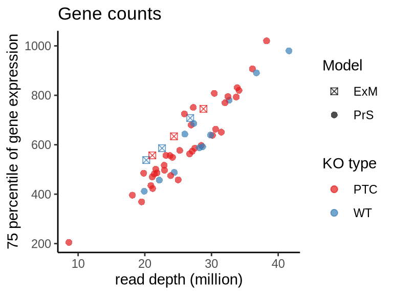

```r
meta$read_depth = colSums(cts_dat)/1e6
meta$q75 = apply(cts_dat, 2, quantile, probs = 0.75)

ggplot(meta, aes(x=read_depth, y=q75, color=ko_strategy, shape = model_system)) +
    geom_point(size=2, alpha=0.7) + ggtitle("Gene counts") +
  scale_shape_manual(values = c(7, 16)) +
  xlab("read depth (million)") + ylab("75 percentile of gene expression") +
  labs(color = "KO type", shape = "Model") +
  scale_color_brewer(palette = "Set1")
```

```r
unique(meta$run_id)
```

```
## [1] "20250207_GT25-RobsonP-14"      "20250121_GT24-RobsonP-137"
## [3] "20240909_GT24-RobsonP-19"      "20241202_GT24-RobsonP-94"
## [5] "20250327_GT25-RobsonP-14-run3"
```

```r
meta$run_id_short = meta$run_id
table(meta$model_system, meta$run_id_short)
```

```
##
##       20240909_GT24-RobsonP-19 20241202_GT24-RobsonP-94
##   ExM                        0                        6
##   PrS                       11                        0
##
##       20250121_GT24-RobsonP-137 20250207_GT25-RobsonP-14
##   ExM                         0                        0
##   PrS                        24                       11
##
##       20250327_GT25-RobsonP-14-run3
##   ExM                             0
##   PrS                             1
```

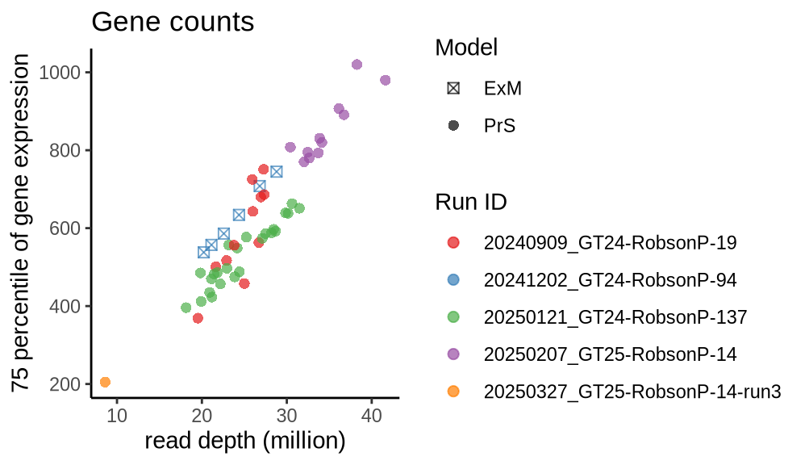

```r
ggplot(meta, aes(x=read_depth, y=q75, color=run_id_short, shape = model_system)) +
    geom_point(size=2, alpha=0.7) + ggtitle("Gene counts") +
  scale_shape_manual(values = c(7, 16)) +
  xlab("read depth (million)") + ylab("75 percentile of gene expression") +
  labs(color = "Run ID", shape = "Model") +
  scale_color_brewer(palette = "Set1")
```

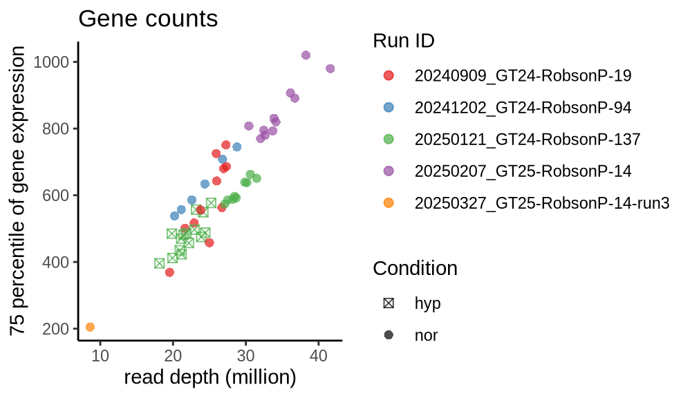

```r
ggplot(meta, aes(x=read_depth, y=q75, color=run_id_short, shape = condition)) +
    geom_point(size=2, alpha=0.7) + ggtitle("Gene counts") +
  scale_shape_manual(values = c(7, 16)) +
  xlab("read depth (million)") + ylab("75 percentile of gene expression") +
  labs(color = "Run ID", shape = "Condition") +
  scale_color_brewer(palette = "Set1")
```

## Check PCA result of WT samples

```r
sample2kp = which(meta$ko_gene == "WT")
cts_dat_m = cts_dat[,sample2kp]
meta_m    = meta[sample2kp,]
summary(meta_m$q75)
```

```
##    Min. 1st Qu.  Median    Mean 3rd Qu.    Max.
##   412.0   550.0   615.5   642.0   702.5   980.0
```

```r
dim(cts_dat_m)
```

```
## [1] 24637    14
```

```r
stopifnot(all(meta_m$file_id == colnames(cts_dat_m)))
table(meta_m$file_id == colnames(cts_dat_m), useNA="ifany")
```

```
##
## TRUE
##   14
```

```r
q75 = apply(cts_dat_m, 1, quantile, probs=0.75)
cts_dat_n = t(cts_dat_m[q75 > 0,])
cts_dat_n = log(median(meta_m$q75)*cts_dat_n/meta_m$q75 + 1)
dim(cts_dat_n)
```

```
## [1]    14 22813
```

```r
sample_pca = prcomp(cts_dat_n, center = TRUE, scale. = TRUE)
names(sample_pca)
```

```
## [1] "sdev"     "rotation" "center"   "scale"    "x"
```

```r
pc_scores = sample_pca$x
eigen_vals = sample_pca$sdev^2
eigen_vals[1:5]/sum(eigen_vals)
```

```
## [1] 0.41718133 0.26067140 0.08679994 0.04939884 0.03000928
```

```r
pvs = round(eigen_vals[1:5]/sum(eigen_vals)*100,1)
pvs
```

```
## [1] 41.7 26.1  8.7  4.9  3.0
```

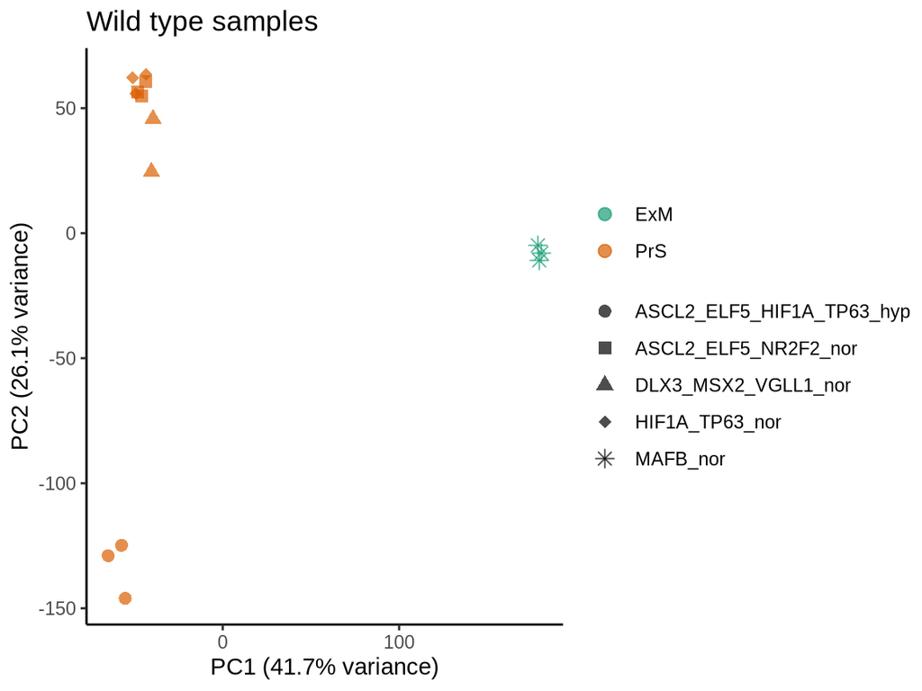

```r
PC_df = data.frame(pc_scores)
PC_df = cbind(PC_df, meta_m)

gPC = ggplot(PC_df, aes(x = PC1, y = PC2, shape=gene_condition_group, color=model_system)) +
  geom_point(size=2.5, alpha=0.7) + scale_color_brewer(palette = "Dark2") +
  scale_shape_prism() +
  labs(color="Model system", shape ="Gene-Condition group") +
  xlab(sprintf("PC1 (%.1f%% variance)", pvs[1])) +
  ylab(sprintf("PC2 (%.1f%% variance)", pvs[2])) +
  ggtitle("Wild type samples") +
  guides(
    color = guide_legend(title = NULL, order = 1),
    shape = guide_legend(title = NULL, order = 2)
  ) +
  theme(
    legend.margin = margin(0, 0, 0, 0),
    legend.box.just = "left",
    legend.direction = "vertical"
  )

print(gPC)
```

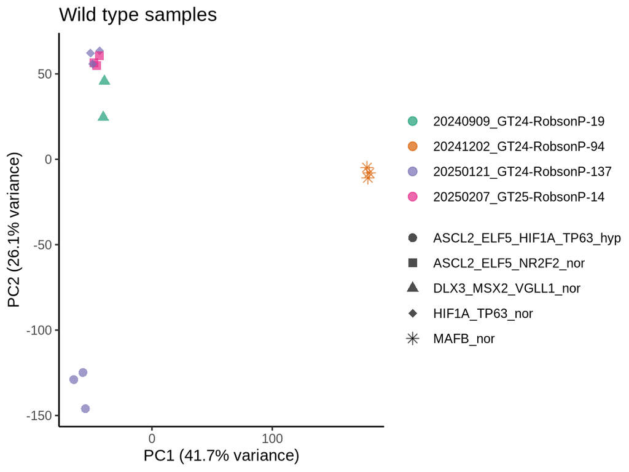

```r
gPC = ggplot(PC_df, aes(x = PC1, y = PC2, shape=gene_condition_group,
                        color=run_id_short)) +
  geom_point(size=2.5, alpha=0.7) +
  scale_color_brewer(palette = "Dark2") +
  scale_shape_prism() +
  labs(color="Run_id", shape ="Gene-Condition group") +
  xlab(sprintf("PC1 (%.1f%% variance)", pvs[1])) +
  ylab(sprintf("PC2 (%.1f%% variance)", pvs[2])) +
  ggtitle("Wild type samples") +
  guides(
    color = guide_legend(title = NULL, order = 1),
    shape = guide_legend(title = NULL, order = 2)
  ) +
  theme(
    legend.margin = margin(0, 0, 0, 0),
    legend.box.just = "left",
    legend.direction = "vertical"
  )

print(gPC)
```

## Analyze samples of different model systems or batches

```r
meta$model_condition = paste(meta$model_system, meta$condition, sep="_")
table(meta$model_condition)
```

```
##
## ExM_nor PrS_hyp PrS_nor
##       6      15      32
```

```r
table(meta$run_id, meta$model_condition)
```

```
##
##                                 ExM_nor PrS_hyp PrS_nor
##   20240909_GT24-RobsonP-19            0       0      11
##   20241202_GT24-RobsonP-94            6       0       0
##   20250121_GT24-RobsonP-137           0      15       9
##   20250207_GT25-RobsonP-14            0       0      11
##   20250327_GT25-RobsonP-14-run3       0       0       1
```

```r
table(meta$run_id, meta$ko_gene)
```

```
##
##                                 ASCL2 DLX3 ELF5 HIF1A MAFB MSX2 NR2F2 TP63
##   20240909_GT24-RobsonP-19          0    3    0     0    0    3     0    0
##   20241202_GT24-RobsonP-94          0    0    0     0    3    0     0    0
##   20250121_GT24-RobsonP-137         3    0    3     6    0    0     0    6
##   20250207_GT25-RobsonP-14          3    0    3     0    0    0     2    0
##   20250327_GT25-RobsonP-14-run3     0    0    0     0    0    0     1    0
##
##                                 VGLL1 WT
##   20240909_GT24-RobsonP-19          3  2
##   20241202_GT24-RobsonP-94          0  3
##   20250121_GT24-RobsonP-137         0  6
##   20250207_GT25-RobsonP-14          0  3
##   20250327_GT25-RobsonP-14-run3     0  0
```

```r
table(meta$run_id, meta$gene_condition_group)
```

```
##
##                                 ASCL2_ELF5_HIF1A_TP63_hyp ASCL2_ELF5_NR2F2_nor
##   20240909_GT24-RobsonP-19                              0                    0
##   20241202_GT24-RobsonP-94                              0                    0
##   20250121_GT24-RobsonP-137                            15                    0
##   20250207_GT25-RobsonP-14                              0                   11
##   20250327_GT25-RobsonP-14-run3                         0                    1
##
##                                 DLX3_MSX2_VGLL1_nor HIF1A_TP63_nor MAFB_nor
##   20240909_GT24-RobsonP-19                       11              0        0
##   20241202_GT24-RobsonP-94                        0              0        6
##   20250121_GT24-RobsonP-137                       0              9        0
##   20250207_GT25-RobsonP-14                        0              0        0
##   20250327_GT25-RobsonP-14-run3                   0              0        0
```

```r
table(meta$ko_strategy, meta$ko_gene)
```

```
##
##       ASCL2 DLX3 ELF5 HIF1A MAFB MSX2 NR2F2 TP63 VGLL1 WT
##   PTC     6    3    6     6    3    3     3    6     3  0
##   WT      0    0    0     0    0    0     0    0     0 14
```

```
## [1] ""
## [1] "=========================================="
## [1] "ExM_nor"
## [1] "=========================================="
## [1] ""
##
## 1
## 6
##
##       PTC WT
##   PTC   3  0
##   WT    0  3
##
##            MAFB WT
##   MAFB_nor    3  3
```

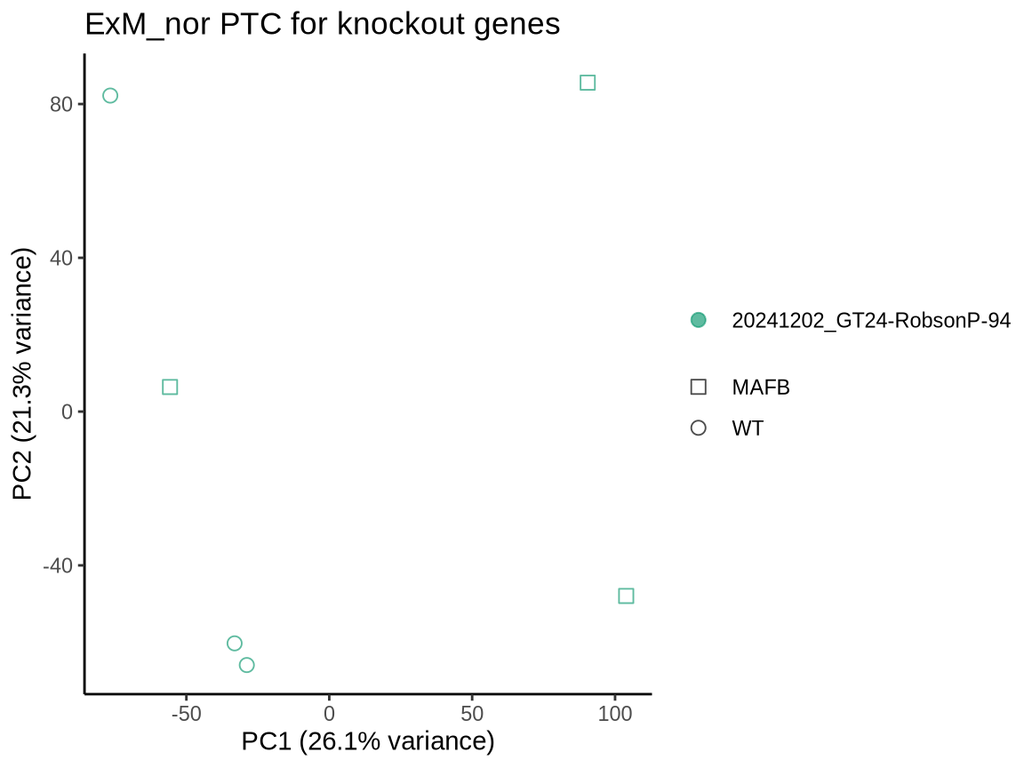

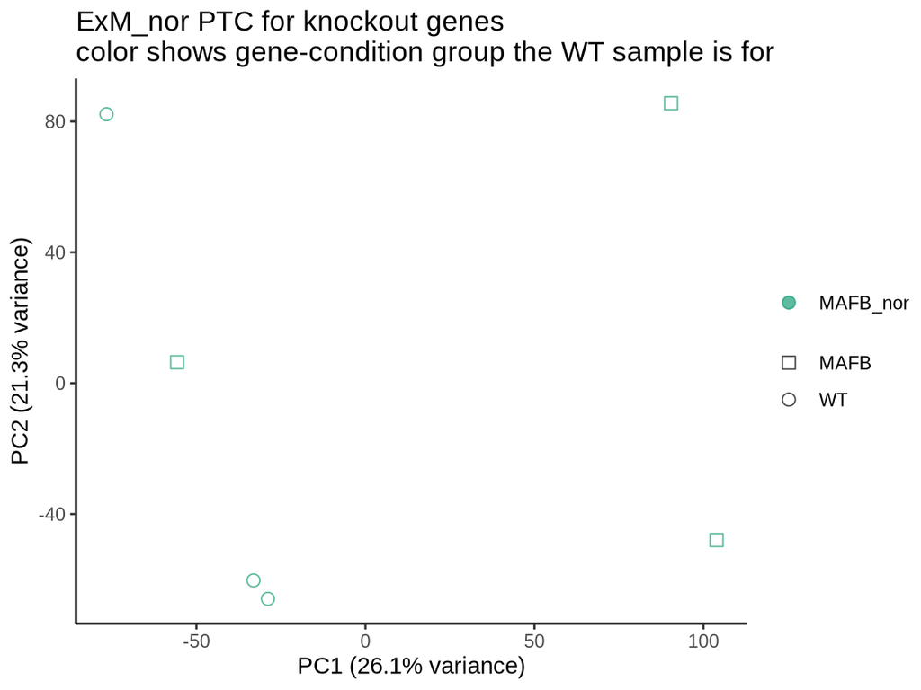

```
## [1] ""
## [1] "=========================================="
## [1] "PrS_hyp"
## [1] "=========================================="
## [1] ""
##
##  1
## 15
##
##       KOLF2 PTC
##   PTC     0  12
##   WT      3   0
##
##                             ASCL2 ELF5 HIF1A TP63 WT
##   ASCL2_ELF5_HIF1A_TP63_hyp     3    3     3    3  3
```

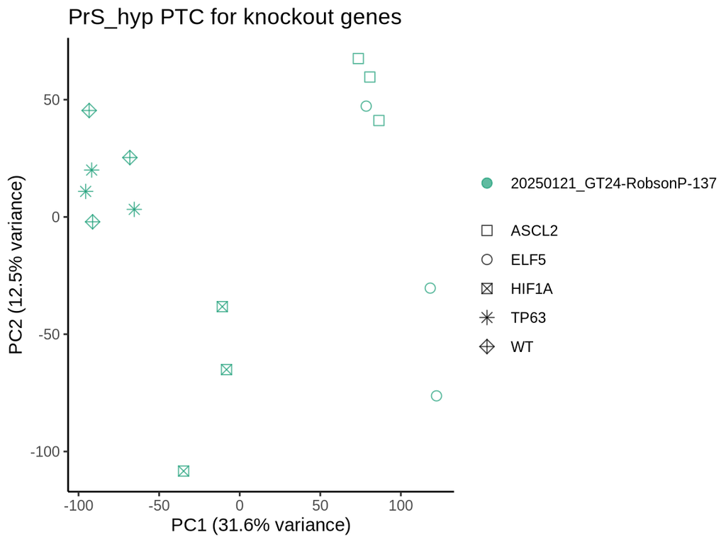

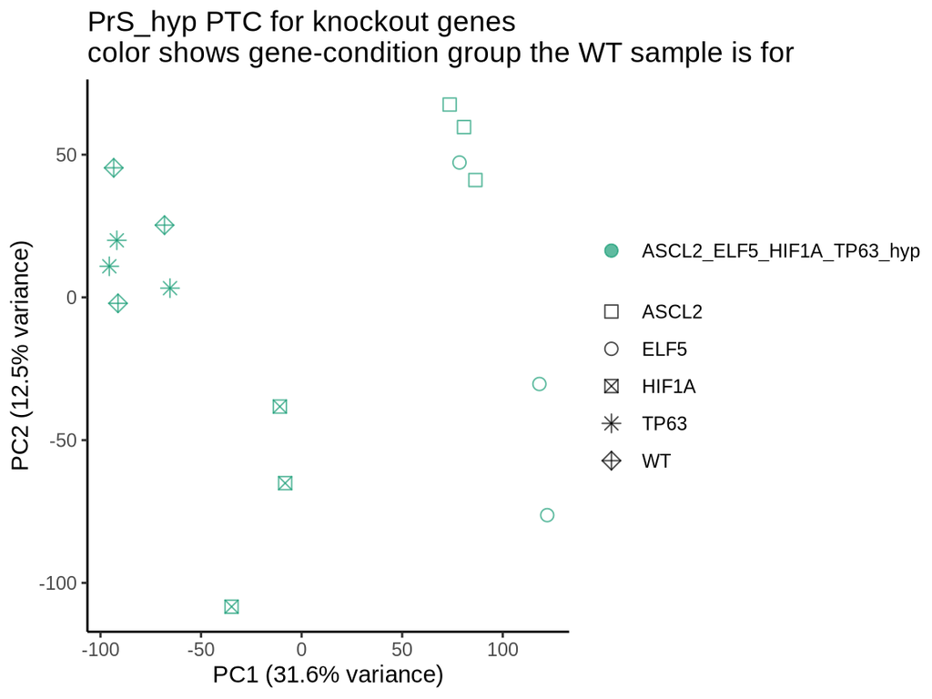

```
## [1] ""
## [1] "=========================================="
## [1] "PrS_nor"
## [1] "=========================================="
## [1] ""
##
##  1
## 32
##
##       KOLF2 PTC WT
##   PTC     0  24  0
##   WT      3   0  5
##
##                        ASCL2 DLX3 ELF5 HIF1A MSX2 NR2F2 TP63 VGLL1 WT
##   ASCL2_ELF5_NR2F2_nor     3    0    3     0    0     3    0     0  3
##   DLX3_MSX2_VGLL1_nor      0    3    0     0    3     0    0     3  2
##   HIF1A_TP63_nor           0    0    0     3    0     0    3     0  3
```

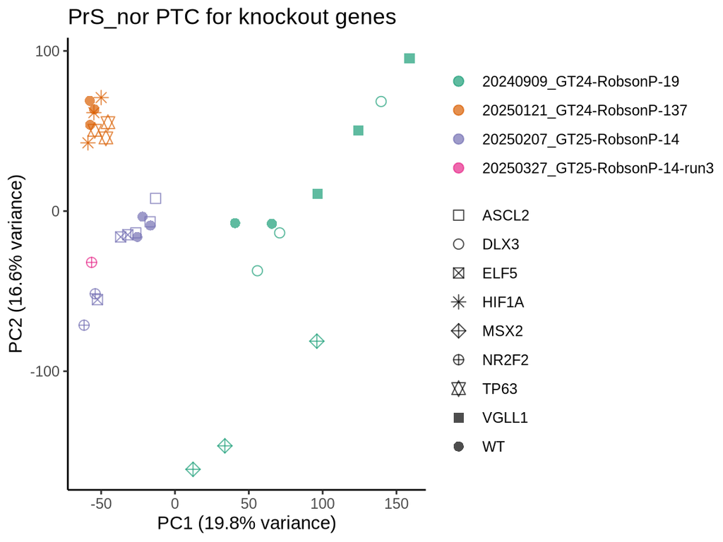

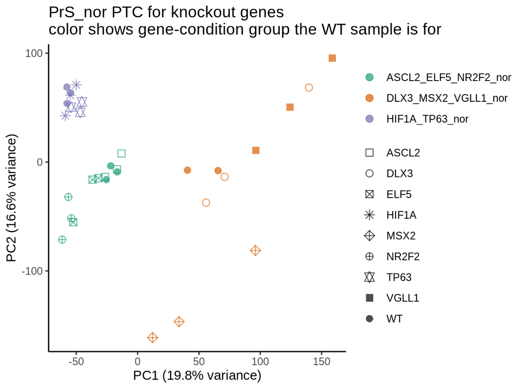

```r
unique_model_condition_ss = unique(meta$model_condition)
unique_model_condition_ss = sort(unique_model_condition_ss)

for(cur_mc in unique_model_condition_ss){
  print("")
  print("==========================================")
  print(cur_mc)
  print("==========================================")
  print("")

  sample2kp = which(meta$model_condition == cur_mc)
  cts_dat_m = cts_dat[,sample2kp]
  meta_m    = meta[sample2kp,]

  # verify the consistency between ko_strategy from metadata column and
  # that from filenames
  extracted_ko_strings = str_extract_all(meta_m$file_id, "PTC|WT|KOLF2")
  print(table(sapply(extracted_ko_strings, length)))
  print(table(meta_m$ko_strategy, unlist(extracted_ko_strings)))

  stopifnot(all(meta_m$file_id == colnames(cts_dat_m)))
  table(meta_m$file_id == colnames(cts_dat_m), useNA="ifany")


  q75 = apply(cts_dat_m, 1, quantile, probs=0.75)

  cts_dat_n = t(cts_dat_m[q75 > 0,])
  cts_dat_n = log(median(meta_m$q75)*cts_dat_n/meta_m$q75 + 1)
  dim(cts_dat_n)

  sample_pca = prcomp(cts_dat_n, center = TRUE, scale. = TRUE)
  names(sample_pca)
  pc_scores = sample_pca$x
  eigen_vals = sample_pca$sdev^2
  eigen_vals[1:5]/sum(eigen_vals)
  pvs = round(eigen_vals[1:5]/sum(eigen_vals)*100,1)
  pvs

  PC_df = data.frame(pc_scores)
  PC_df = cbind(PC_df, meta_m)

  colnames(PC_df)[which(colnames(PC_df)=="timepoint")] = "day"

  only_ko_strategy = setdiff(unique(PC_df$ko_strategy), "WT")

  unique_ko_genes = sort(unique(PC_df$ko_gene))
  unique_ko_genes = c(unique_ko_genes[unique_ko_genes!="WT"], "WT")
  PC_df$ko_gene = factor(PC_df$ko_gene, unique_ko_genes)

  print(table(PC_df$gene_condition_group, PC_df$ko_gene, useNA="ifany"))

  shapes = c(0, 1, 7, 8, 9, 10, 11, 15, 16, 17)


  table(meta_m$clonal.description, meta_m$timepoint)

  gPC = ggplot(PC_df, aes(x = PC1, y = PC2, shape=ko_gene, color=run_id_short)) +
              geom_point(size=2.5, alpha=0.7) +
              scale_color_brewer(palette = "Dark2") +
              scale_shape_manual(values = shapes[1:length(unique(PC_df$ko_gene))]) +
              xlab(sprintf("PC1 (%.1f%% variance)", pvs[1])) +
              ylab(sprintf("PC2 (%.1f%% variance)", pvs[2])) +
              ggtitle(paste0(cur_mc, " ", only_ko_strategy, " for knockout genes")) +
              guides(
                color = guide_legend(title = NULL, order = 1),
                shape = guide_legend(title = NULL, order = 2)
              ) +
              theme(
                legend.margin = margin(0, 0, 0, 0),
                legend.box.just = "left",
                legend.direction = "vertical"
              )

  print(gPC)

  gPC = ggplot(PC_df, aes(x = PC1, y = PC2, shape=ko_gene, color=gene_condition_group)) +
              geom_point(size=2.5, alpha=0.7) + scale_color_brewer(palette = "Dark2") +
                scale_shape_manual(values = shapes[1:length(unique(PC_df$ko_gene))]) +
              xlab(sprintf("PC1 (%.1f%% variance)", pvs[1])) +
              ylab(sprintf("PC2 (%.1f%% variance)", pvs[2])) +
              ggtitle(paste0(cur_mc, " ", only_ko_strategy, " for knockout genes\n",
                             "color shows gene-condition group the WT sample is for")) +
              guides(
                color = guide_legend(title = NULL, order = 1),
                shape = guide_legend(title = NULL, order = 2)
              ) +
              theme_classic() +
              theme(
                legend.margin = margin(0, 0, 0, 0),
                legend.box.just = "left",
                legend.direction = "vertical"
              )

  print(gPC)

}
```

Run DE analysis for each gene-condition level separately. They natually separate all batches, except for one sample from 20250327_GT25-RobsonP-14-run3, which presents no batch effect based on the PC plot.

```r
table(meta$gene_condition_group, meta$run_id, meta$model_system, meta$timepoint)
```

```
## , ,  = ExM,  = 6
##
##
##                             20240909_GT24-RobsonP-19 20241202_GT24-RobsonP-94
##   ASCL2_ELF5_HIF1A_TP63_hyp                        0                        0
##   ASCL2_ELF5_NR2F2_nor                             0                        0
##   DLX3_MSX2_VGLL1_nor                              0                        0
##   HIF1A_TP63_nor                                   0                        0
##   MAFB_nor                                         0                        6
##
##                             20250121_GT24-RobsonP-137 20250207_GT25-RobsonP-14
##   ASCL2_ELF5_HIF1A_TP63_hyp                         0                        0
##   ASCL2_ELF5_NR2F2_nor                              0                        0
##   DLX3_MSX2_VGLL1_nor                               0                        0
##   HIF1A_TP63_nor                                    0                        0
##   MAFB_nor                                          0                        0
##
##                             20250327_GT25-RobsonP-14-run3
##   ASCL2_ELF5_HIF1A_TP63_hyp                             0
##   ASCL2_ELF5_NR2F2_nor                                  0
##   DLX3_MSX2_VGLL1_nor                                   0
##   HIF1A_TP63_nor                                        0
##   MAFB_nor                                              0
##
## , ,  = PrS,  = 6
##
##
##                             20240909_GT24-RobsonP-19 20241202_GT24-RobsonP-94
##   ASCL2_ELF5_HIF1A_TP63_hyp                        0                        0
##   ASCL2_ELF5_NR2F2_nor                             0                        0
##   DLX3_MSX2_VGLL1_nor                             11                        0
##   HIF1A_TP63_nor                                   0                        0
##   MAFB_nor                                         0                        0
##
##                             20250121_GT24-RobsonP-137 20250207_GT25-RobsonP-14
##   ASCL2_ELF5_HIF1A_TP63_hyp                        15                        0
##   ASCL2_ELF5_NR2F2_nor                              0                       11
##   DLX3_MSX2_VGLL1_nor                               0                        0
##   HIF1A_TP63_nor                                    9                        0
##   MAFB_nor                                          0                        0
##
##                             20250327_GT25-RobsonP-14-run3
##   ASCL2_ELF5_HIF1A_TP63_hyp                             0
##   ASCL2_ELF5_NR2F2_nor                                  1
##   DLX3_MSX2_VGLL1_nor                                   0
##   HIF1A_TP63_nor                                        0
##   MAFB_nor                                              0
```

For the output files, create two versions, one with direct information, one with padj set to NA for the genes when the number of 0 per test is >=4.

In more details, for both versions of the outputs, make it one file per knockout gene per DE group (DE group can be model system, model system + condition, model system + run_id, model system + day, etc.).

The first version of the output files contains

[output not shown]

and for each knockout strategy:

```
baseMean, log2FoldChange, lfcSE, stat, pvalue, padj
```

The second version of the output files contains

```
gene id, gene symbol, chr, strand, position
```

and for each knockout strategy:

```
log2FoldChange, pvalue, padj (set to be NA if the number of 0 per test >= 4).
```

In addition, save out a separate file of the sample size for each comparison. This needs to be by DE group.

### Prepare output directories for DE results

```r
release_name = "2025_06_JAX_RNAseq08"

output_dir = file.path("results", release_name)
raw_output_dir = file.path(output_dir, "raw")
processed_output_dir = file.path(output_dir, "processed")

if (!file.exists(raw_output_dir)){
  dir.create(raw_output_dir, recursive = TRUE)
}

if (!file.exists(processed_output_dir)){
  dir.create(processed_output_dir, recursive = TRUE)
}
```

### DE analysis for all genes

```
## [1] ""
## [1] "=========================================="
## [1] "ExM"
## [1] "=========================================="
## [1] ""
##
##                            MAFB WT
##   20241202_GT24-RobsonP-94    3  3
##
##        6
##   MAFB 3
##   WT   3
##
##                 6
##   MAFB_MAFB_nor 3
##   WT_MAFB_nor   3
## [1] "---------------------------"
## [1] "Model system: ExM"
## [1] "On day_condition 6_nor: "
## [1] "Cross table between knockout gene and run id:"
##
##        20241202_GT24-RobsonP-94
##   MAFB                        3
##   WT                          3
## [1] "Cross table between knockout gene and knockout gene group:"
##
##        MAFB_nor
##   MAFB        3
##   WT          3
## [1] ""
## [1] "-----------------------------------"
## [1] "Model system: ExM"
## [1] "DE group ExM_day_6 DESeq2 results:"
## [1] "-----------------------------------"
## [1] "After filtering by gene expression q75, the number of genes reduces from 24637 to 22870"
## [1] "After filtering by nonzero expression in at least 4 samples, the number of genes reduces from 22870 to 20321"
## Time difference of 13.70697 secs
```

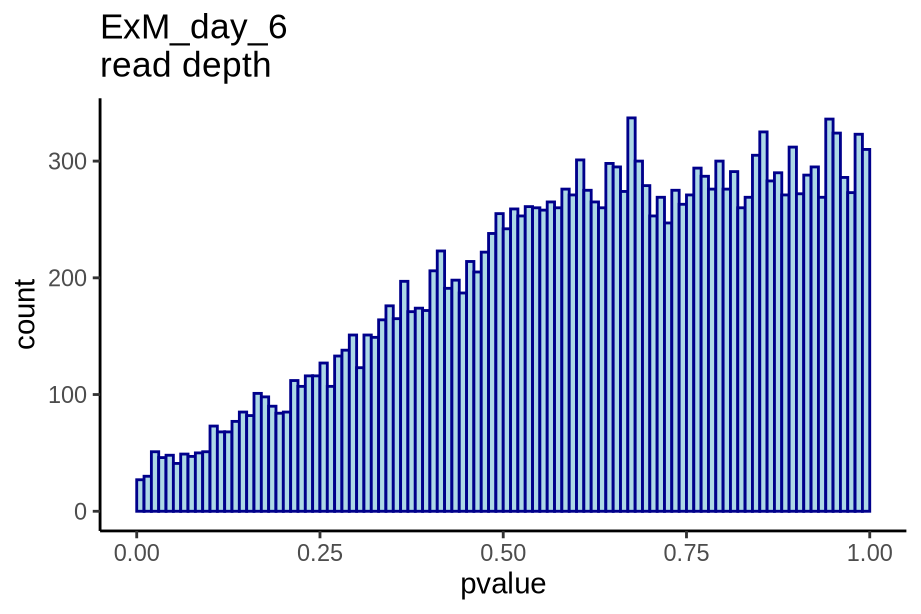

```
## [1] "prop of non-null for rd: 0.00e+00"
## [1] "rerun DESeq2 without read depth"
## [1] "ExM_day_6 under KO gene MAFB:"
## [1] "number of DE genes: 7"
```

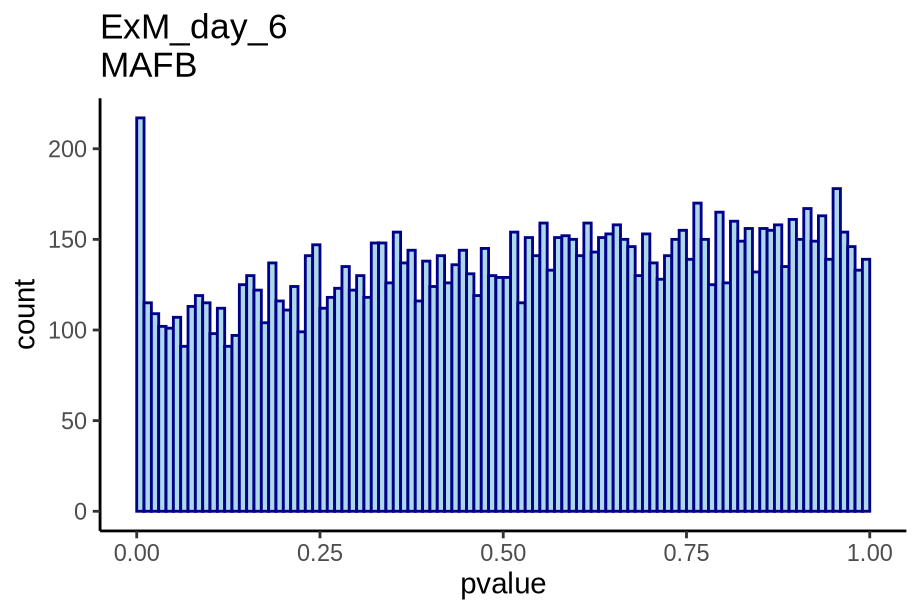

```
## [1] "hgnc_symbol empty string and NA tables:"
##
## FALSE  <NA>
## 17465  2856
##
## FALSE  TRUE
## 17465  2856
## [1] ""
## [1] "=========================================="
## [1] "PrS"
## [1] "=========================================="
## [1] ""
##
##                                 ASCL2 DLX3 ELF5 HIF1A MSX2 NR2F2 TP63 VGLL1 WT
##   20240909_GT24-RobsonP-19          0    3    0     0    3     0    0     3  2
##   20250121_GT24-RobsonP-137         3    0    3     6    0     0    6     0  6
##   20250207_GT25-RobsonP-14          3    0    3     0    0     2    0     0  3
##   20250327_GT25-RobsonP-14-run3     0    0    0     0    0     1    0     0  0
##
##          6
##   ASCL2  6
##   DLX3   3
##   ELF5   6
##   HIF1A  6
##   MSX2   3
##   NR2F2  3
##   TP63   6
##   VGLL1  3
##   WT    11
##
##                                   6
##   ASCL2_ASCL2_ELF5_HIF1A_TP63_hyp 3
##   ASCL2_ASCL2_ELF5_NR2F2_nor      3
##   DLX3_DLX3_MSX2_VGLL1_nor        3
##   ELF5_ASCL2_ELF5_HIF1A_TP63_hyp  3
##   ELF5_ASCL2_ELF5_NR2F2_nor       3
##   HIF1A_ASCL2_ELF5_HIF1A_TP63_hyp 3
##   HIF1A_HIF1A_TP63_nor            3
##   MSX2_DLX3_MSX2_VGLL1_nor        3
##   NR2F2_ASCL2_ELF5_NR2F2_nor      3
```

[output cut: 57 more lines]

```
##   ELF5                     3                   0              0
##   HIF1A                    0                   0              3
##   MSX2                     0                   3              0
##   NR2F2                    3                   0              0
##   TP63                     0                   0              3
##   VGLL1                    0                   3              0
##   WT                       3                   2              3
## [1] ""
## [1] "-----------------------------------"
## [1] "Model system: PrS"
## [1] "DE group PrS_day_6_hyp_ASCL2_ELF5_HIF1A_TP63_hyp DESeq2 results:"
## [1] "-----------------------------------"
## [1] "After filtering by gene expression q75, the number of genes reduces from 24637 to 22499"
## [1] "After filtering by nonzero expression in at least 4 samples, the number of genes does not change."
## Time difference of 44.02438 secs
```

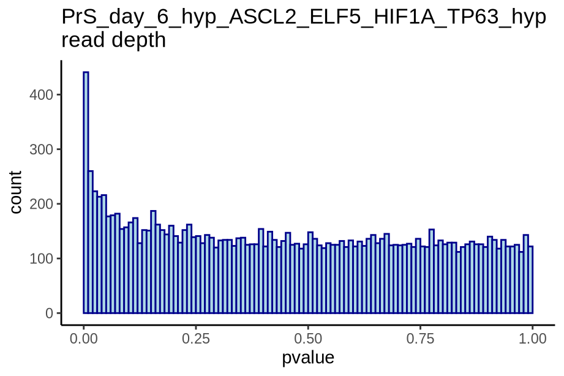

```
## [1] "prop of non-null for rd: 9.80e-02"
## [1] "PrS_day_6_hyp_ASCL2_ELF5_HIF1A_TP63_hyp under KO gene ASCL2:"
## [1] "number of DE genes: 2234"
```

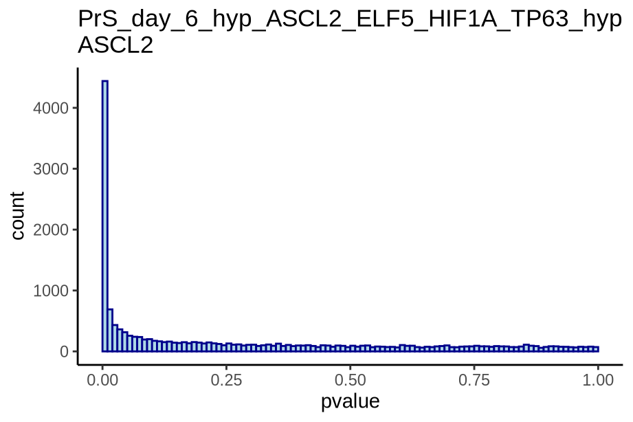

```
## [1] "hgnc_symbol empty string and NA tables:"
##
## FALSE  <NA>
## 18733  3766
##
## FALSE  TRUE
## 18733  3766
## [1] "PrS_day_6_hyp_ASCL2_ELF5_HIF1A_TP63_hyp under KO gene ELF5:"
## [1] "number of DE genes: 3243"
```

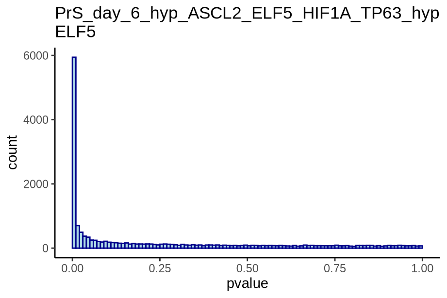

```
## [1] "hgnc_symbol empty string and NA tables:"
##
## FALSE  <NA>
## 18733  3766
##
## FALSE  TRUE
## 18733  3766
## [1] "PrS_day_6_hyp_ASCL2_ELF5_HIF1A_TP63_hyp under KO gene HIF1A:"
## [1] "number of DE genes: 1112"
```

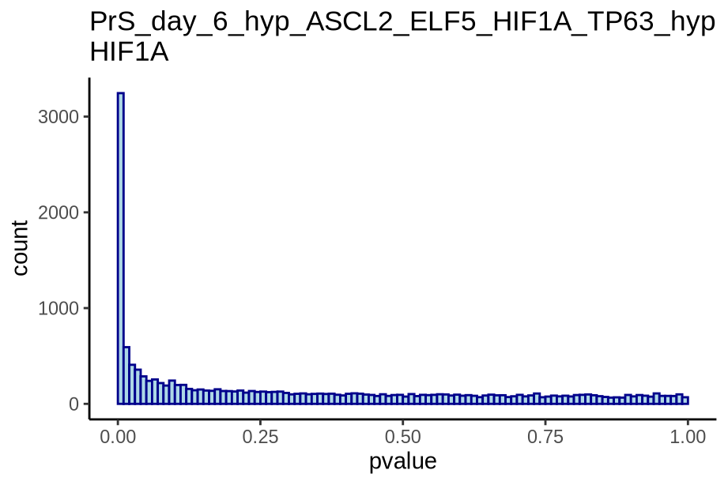

```
## [1] "hgnc_symbol empty string and NA tables:"
##
## FALSE  <NA>
## 18733  3766
##
## FALSE  TRUE
## 18733  3766
## [1] "PrS_day_6_hyp_ASCL2_ELF5_HIF1A_TP63_hyp under KO gene TP63:"
## [1] "number of DE genes: 39"
```

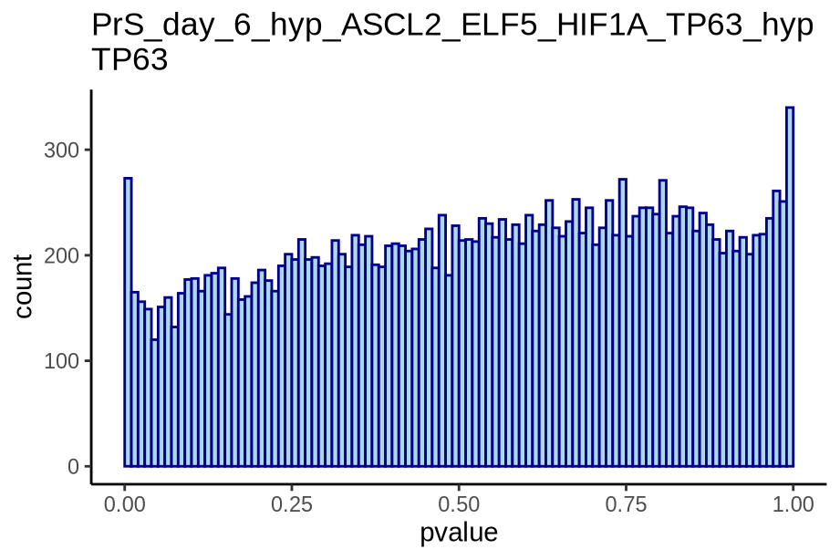

```
## [1] "hgnc_symbol empty string and NA tables:"
##
## FALSE  <NA>
## 18733  3766
##
## FALSE  TRUE
## 18733  3766
## [1] ""
## [1] "-----------------------------------"
## [1] "Model system: PrS"
## [1] "DE group PrS_day_6_nor_ASCL2_ELF5_NR2F2_nor DESeq2 results:"
## [1] "-----------------------------------"
## [1] "After filtering by gene expression q75, the number of genes reduces from 24637 to 22145"
## [1] "After filtering by nonzero expression in at least 4 samples, the number of genes reduces from 22145 to 21473"
## [1] "Ignoring run_id covariate for PrS_day_6_nor_ASCL2_ELF5_NR2F2_nor"
## Time difference of 6.84924 secs
```

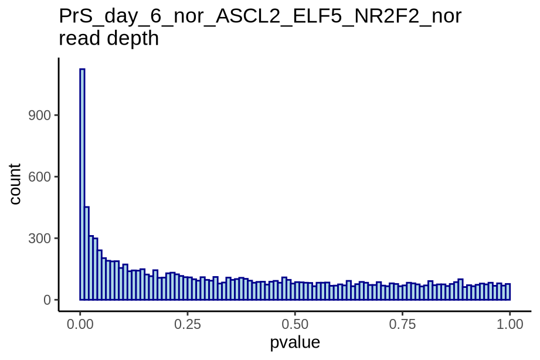

```
## [1] "prop of non-null for rd: 3.36e-01"
## [1] "PrS_day_6_nor_ASCL2_ELF5_NR2F2_nor under KO gene ASCL2:"
## [1] "number of DE genes: 0"
```

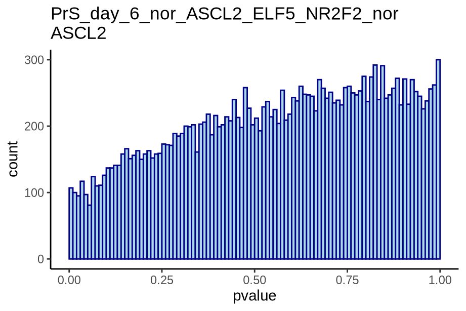

```
## [1] "hgnc_symbol empty string and NA tables:"
##
## FALSE  <NA>
## 18260  3213
##
## FALSE  TRUE
## 18260  3213
## [1] "PrS_day_6_nor_ASCL2_ELF5_NR2F2_nor under KO gene ELF5:"
## [1] "number of DE genes: 76"
```

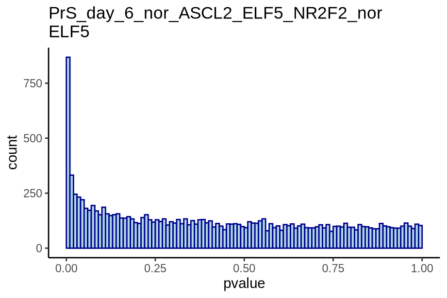

```
## [1] "hgnc_symbol empty string and NA tables:"
##
## FALSE  <NA>
## 18260  3213
##
## FALSE  TRUE
## 18260  3213
## [1] "PrS_day_6_nor_ASCL2_ELF5_NR2F2_nor under KO gene NR2F2:"
## [1] "number of DE genes: 1538"
```

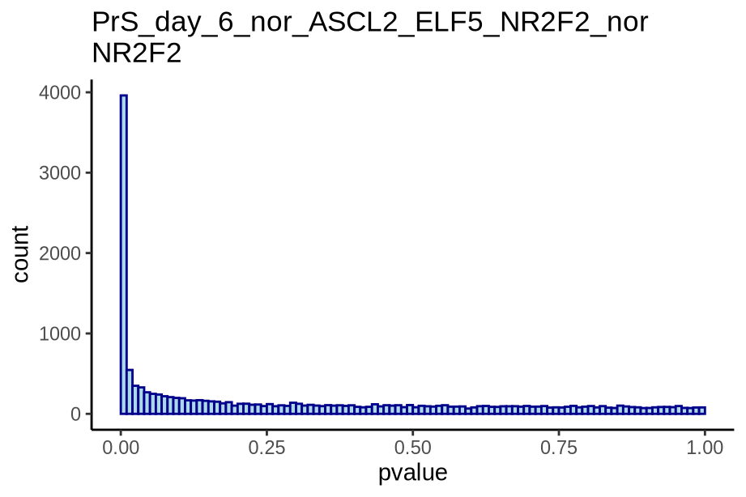

```
## [1] "hgnc_symbol empty string and NA tables:"
##
## FALSE  <NA>
## 18260  3213
##
## FALSE  TRUE
## 18260  3213
## [1] ""
## [1] "-----------------------------------"
## [1] "Model system: PrS"
## [1] "DE group PrS_day_6_nor_DLX3_MSX2_VGLL1_nor DESeq2 results:"
## [1] "-----------------------------------"
## [1] "After filtering by gene expression q75, the number of genes reduces from 24637 to 22479"
## [1] "After filtering by nonzero expression in at least 4 samples, the number of genes reduces from 22479 to 21782"
## Time difference of 17.41527 secs
```

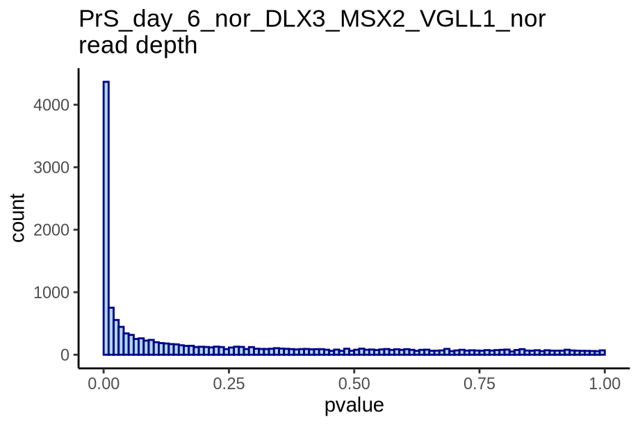

```
## [1] "prop of non-null for rd: 5.43e-01"
## [1] "PrS_day_6_nor_DLX3_MSX2_VGLL1_nor under KO gene DLX3:"
## [1] "number of DE genes: 1877"
```

[6 more figures not shown]

```
## [1] "hgnc_symbol empty string and NA tables:"
##
## FALSE  <NA>
## 17733  2867
##
## FALSE  TRUE
## 17733  2867
```

```r
df_size = NULL

unique_model_ss = unique(meta$model_system)
unique_model_ss = sort(unique_model_ss)

for(model1 in unique_model_ss){

  print("")
  print("==========================================")
  print(model1)
  print("==========================================")
  print("")

  sample2kp = which(meta$model_system == model1)

  cts_dat_m = cts_dat[,sample2kp]
  meta_m    = meta[sample2kp,]

  table(meta_m$ko_strategy)
  stopifnot(all(meta_m$file_id == colnames(cts_dat_m)))

  ## Generate sample information matrix
  cols2kp = c("model_system", "condition", "ko_strategy", "ko_gene", "gene_condition_group",
              "run_id", "run_id_short", "timepoint", "q75")
  sample_info = meta_m[,cols2kp]
  colnames(sample_info)[which(colnames(sample_info)=="timepoint")] = "day"

  dim(sample_info)
  sample_info[1:2,]

  sample_info$ko_gene_gene_condition_group = paste(sample_info$ko_gene,
                                         sample_info$gene_condition_group, sep="_")

  print(table(sample_info$run_id, sample_info$ko_gene))
  print(table(sample_info$ko_gene, sample_info$day))
  print(table(sample_info$ko_gene_gene_condition_group, sample_info$day))

  # print the table of ko_gene and run_id by (day, condition) combinations
  sample_info$day_condition = paste0(sample_info$day, "_", sample_info$condition)
  unique_day_condition_model_s = unique(sample_info$day_condition)
  unique_day_condition_model_s = as.character(sort(unique_day_condition_model_s))

  for (cur_d_c in as.character(unique_day_condition_model_s)){
    sample_info_by_day = sample_info[which(sample_info$day_condition==as.character(cur_d_c)), ]
    print("---------------------------")
    print(paste0("Model system: ", model1))
    print(paste0("On day_condition ", as.character(cur_d_c), ": "))
    print("Cross table between knockout gene and run id:")
    print(table(sample_info_by_day$ko_gene, sample_info_by_day$run_id_short))
    print("Cross table between knockout gene and knockout gene group:")
    print(table(sample_info_by_day$ko_gene, sample_info_by_day$gene_condition_group))
  }

  sample_info$model_day = paste0(sample_info$model_system,
                                 "_day_",
                                 as.character(sample_info$day))

  sample_info$de_grp = sample_info$model_day

  if(model1 == "PrS"){
    sample_info$de_grp = paste0(sample_info$de_grp, "_",
                                sample_info$condition, "_",
                                sample_info$gene_condition_group)
  }

  unique_de_grps = unique(sample_info$de_grp)
  sorted_de_grps = sort(unique_de_grps)

  for (d_group in sorted_de_grps){

    dg_index = which(sample_info$de_grp==d_group)
    cts_dat_m_dg = cts_dat_m[, dg_index]
    sample_info_dg = sample_info[dg_index, ]

    stopifnot(all(sample_info_dg$de_grp==d_group))

    print("")
    print("-----------------------------------")
    print(paste0("Model system: ", model1))
    if (sum(sample_info_dg$ko_gene=="WT") < 2){
      print(sprintf("DE group %s has only %d wild type samples",
                    d_group, sum(sample_info_dg$ko_gene=="WT")))
      print(sprintf("do not run DESeq2 for it"))
      print("-----------------------------------")
      next
    }else{
      print(sprintf("DE group %s DESeq2 results:", d_group))
      print("-----------------------------------")
    }


    # do two steps of filtering
    # first, filter based on q75 of each gene
    # second, filter based on whether each gene is expressed in at least 4 cells

    dg_q75 = apply(cts_dat_m_dg, 1, quantile, probs=0.75)
    cts_dat_m_dg = cts_dat_m_dg[dg_q75 > 0,]

    print(sprintf("After filtering by gene expression q75, the number of genes reduces from %d to %d",
                  length(dg_q75), nrow(cts_dat_m_dg)))

    n_pos = rowSums(cts_dat_m_dg>0)
    cts_dat_m_dg = cts_dat_m_dg[n_pos >= 4,]

    if (length(n_pos)==nrow(cts_dat_m_dg)){
      print("After filtering by nonzero expression in at least 4 samples, the number of genes does not change.")
    }else{
      print(sprintf("After filtering by nonzero expression in at least 4 samples, the number of genes reduces from %d to %d",
                    length(n_pos), nrow(cts_dat_m_dg)))
    }

    # update the q75 based on only genes that will be used in the DE analysis
    sample_info_dg$q75 = apply(cts_dat_m_dg, 2, quantile, probs = 0.75)
    sample_info_dg$log_q75 = log(sample_info_dg$q75)

    if (d_group == 'PrS_day_6_nor_ASCL2_ELF5_NR2F2_nor') {
      sample_info_dg$run_id = 'edited'
      print('Ignoring run_id covariate for PrS_day_6_nor_ASCL2_ELF5_NR2F2_nor')
    }

    if (length(unique(sample_info_dg$run_id))==1){
      dds = DESeqDataSetFromMatrix(cts_dat_m_dg, colData=sample_info_dg,
                                    ~ ko_gene + log_q75)
    }else{
      dds = DESeqDataSetFromMatrix(cts_dat_m_dg, colData=sample_info_dg,
                                    ~ ko_gene + run_id + log_q75)
    }

    start.time <- Sys.time()
    dds = DESeq(dds)
    end.time <- Sys.time()

    time.taken <- end.time - start.time
    print(time.taken)

    ## association with read-depth
    res_rd = results(dds, name = "log_q75")
    res_rd = as.data.frame(res_rd)
    dim(res_rd)
    res_rd[1:2,]

    table(is.na(res_rd$padj))

    g0 = ggplot(res_rd %>% subset(!is.na(padj)), aes(x=pvalue)) +
      geom_histogram(color="darkblue", fill="lightblue",
                     breaks = seq(0,1,by=0.01)) +
      ggtitle(paste0(d_group, "\nread depth"))
    print(g0)

    ## Rerun the analysis without read-depth if it is not significant for
    ## most genes, and the number of samples is small
    ## i.e., proportion of non-null in the distribution is smaller than 0.01
    ## (this needs to be restricted to the genes with not NA adjusted pvalue)
    ## or if smaller than 0.1 and the number of samples is not greater than 6

    pi_1_rd = max(0, mean(res_rd$pvalue[!is.na(res_rd$padj)] < 0.05) - 0.05)
    pi_1_rd = max(pi_1_rd, 0, 1 - 2*mean(res_rd$pvalue[!is.na(res_rd$padj)] > 0.5))

    print(sprintf("prop of non-null for rd: %.2e", pi_1_rd))

    if(pi_1_rd < 0.01 || (ncol(cts_dat_m_dg) <= 6 && pi_1_rd < 0.1 )){

      print("rerun DESeq2 without read depth")

      include_rd = 0

      if (length(unique(sample_info_dg$run_id))==1){
        dds = DESeqDataSetFromMatrix(cts_dat_m_dg, colData=sample_info_dg,
                                      ~ ko_gene)
      }else{
        dds = DESeqDataSetFromMatrix(cts_dat_m_dg, colData=sample_info_dg,
                                      ~ ko_gene + run_id)
      }

      dds = DESeq(dds)

    }else{
      include_rd = 1
    }

    ## association with run_id

    if (length(unique(sample_info_dg$run_id))>1){
      if(include_rd)
        dds_lrt = DESeq(dds, test="LRT", reduced = ~ ko_gene + log_q75)
      else
        dds_lrt = DESeq(dds, test="LRT", reduced = ~ ko_gene)

      res_lrt = results(dds_lrt)

      res_run_id = as.data.frame(res_lrt)
      dim(res_run_id)
      res_run_id[1:2,]

      table(is.na(res_run_id$padj))

      g0 = ggplot(res_run_id %>% subset(!is.na(padj)), aes(x=pvalue)) +
        geom_histogram(color="darkblue", fill="lightblue",
                       breaks = seq(0,1,by=0.01)) +
        ggtitle(paste0(d_group, "\nRun ID"))
      print(g0)

    }

    ## DE analysis for each KO gene
    table(sample_info_dg$ko_gene)

    genos = setdiff(unique(sample_info_dg$ko_gene), "WT")
    genos = sort(genos)

    for(geno in genos){

      res_g1 = results(dds, contrast = c("ko_gene", geno, "WT"))
      res_g1 = signif(data.frame(res_g1), 3)

      # add a column to record the number of zeros per test
      test_index = which(sample_info_dg$ko_gene%in%c(geno, "WT"))

      cts_dat_m_dg_test = cts_dat_m_dg[, test_index]
      n_zero = rowSums(cts_dat_m_dg_test==0)
      res_g1$n_zeros = n_zero

      # record the number of samples involved in the comparison
      test_ko_gene_vec = sample_info_dg$ko_gene[test_index]

      df_size = rbind(df_size,
                      c(d_group,
                        paste0(geno, "_PTC"),
                        sum(test_ko_gene_vec!="WT"),
                        sum(test_ko_gene_vec=="WT")))

      # prepare a processed version of output
      res_g1_reduced = res_g1[, c("log2FoldChange", "pvalue", "padj", "n_zeros")]
      res_g1_reduced$padj[which(res_g1_reduced$n_zeros>=4)] = NA

      if ((sum(test_ko_gene_vec!="WT")==1)|(sum(test_ko_gene_vec=="WT")==1)){
        res_g1_reduced$padj = NA
      }

      res_g1_reduced = res_g1_reduced[, c("log2FoldChange", "pvalue", "padj")]

      n_DE = sum(res_g1_reduced$padj < 0.05 & abs(res_g1_reduced$log2FoldChange) > log2(1.5),
                 na.rm = TRUE)
      print(paste0(d_group, " under KO gene ", geno, ":"))
      print(sprintf("number of DE genes: %d", n_DE))

      g1 = ggplot(res_g1_reduced %>% subset(!is.na(padj)), aes(x=pvalue)) +
        geom_histogram(color="darkblue", fill="lightblue",
                       breaks = seq(0,1,by=0.01)) +
        ggtitle(paste0(d_group, "\n", geno))
      print(g1)

      tag1 = sprintf("%s_PTC_", geno)
      colnames(res_g1) = paste0(tag1, colnames(res_g1))
      colnames(res_g1_reduced) = paste0(tag1, colnames(res_g1_reduced))


      res_df = data.frame(gene_ID=rownames(res_g1),
                          res_g1)
      dim(res_df)
      res_df[1:2,]


      res_reduced_gene_anno = gene_anno[match(rownames(res_g1_reduced),
                                              gene_anno$ensembl_gene_id), ]
      stopifnot(all(rownames(res_g1_reduced)==res_reduced_gene_anno$ensembl_gene_id))

      # set gene hgnc_symbol that equal "" to NA
      hgnc_symbol_vec = res_reduced_gene_anno$hgnc_symbol
      hgnc_symbol_vec[which(hgnc_symbol_vec=="")] = NA

      res_reduced_df = data.frame(gene_ID=rownames(res_g1_reduced),
                                  hgnc_symbol=hgnc_symbol_vec,
                                  chr=res_reduced_gene_anno$chr,
                                  strand=res_reduced_gene_anno$strand,
                                  start=res_reduced_gene_anno$start,
                                  end=res_reduced_gene_anno$end,
                                  res_g1_reduced)

      print("hgnc_symbol empty string and NA tables:")
      print(table(res_reduced_df$hgnc_symbol=="", useNA="ifany"))
      print(table(is.na(res_reduced_df$hgnc_symbol)))

      dim(res_reduced_df)
      res_reduced_df[1:2,]

      if (model1=="PrS"){
        setting_name = unique(paste0(sample_info_dg$model_day, "_",
                                     sample_info_dg$condition))
      }else{
        setting_name = unique(sample_info_dg$model_day)
      }

      fwrite(res_df,
             sprintf("%s/%s_%s_%s_DEseq2_raw.tsv",
                     raw_output_dir, release_name, setting_name, geno),
             sep="\t")
      fwrite(res_reduced_df,
             sprintf("%s/%s_%s_%s_DEseq2.tsv",
                     processed_output_dir, release_name, setting_name, geno),
             sep="\t")

    }

  }

}
```

```r
colnames(df_size) = c("DE_group", "knockout_gene_strategy", "n_ko", "n_WT")
df_size = as.data.frame(df_size)

multi_rows = which(table(df_size$knockout_gene_strategy)>1)
multi_rows
```

```
## ASCL2_PTC  ELF5_PTC HIF1A_PTC  TP63_PTC
##         1         3         4         8
```

```r
df_size[which(df_size$knockout_gene_strategy%in%names(multi_rows)),]
```

```
##                                   DE_group knockout_gene_strategy n_ko n_WT
## 2  PrS_day_6_hyp_ASCL2_ELF5_HIF1A_TP63_hyp              ASCL2_PTC    3    3
## 3  PrS_day_6_hyp_ASCL2_ELF5_HIF1A_TP63_hyp               ELF5_PTC    3    3
## 4  PrS_day_6_hyp_ASCL2_ELF5_HIF1A_TP63_hyp              HIF1A_PTC    3    3
## 5  PrS_day_6_hyp_ASCL2_ELF5_HIF1A_TP63_hyp               TP63_PTC    3    3
## 6       PrS_day_6_nor_ASCL2_ELF5_NR2F2_nor              ASCL2_PTC    3    3
## 7       PrS_day_6_nor_ASCL2_ELF5_NR2F2_nor               ELF5_PTC    3    3
## 12            PrS_day_6_nor_HIF1A_TP63_nor              HIF1A_PTC    3    3
## 13            PrS_day_6_nor_HIF1A_TP63_nor               TP63_PTC    3    3
```

```r
fwrite(df_size,
       sprintf("%s/%s_DE_n_samples.tsv", output_dir, release_name),
       sep="\t")
```

## DE analysis with respect to condition (hypoxia vs. normoxia)

This is only relevant for model system PrS.

Within model system PrS, for WT samples, use all WT samples (3 hypoxia for ASCL2_ELF5_HIF1A_TP63_hyp, 8 normoxia for ASCL2_ELF5_NR2F2_nor, DLX3_MSX2_VGLL1_nor, HIF1A_TP63_nor) for this analysis.

Samples invoved: 11 WT, 6 ASCL2, 6 ELF5, 6 HIF1A, 6 TP63. For KO samples, half of them are under normoxia and the other half are under hypoxia.

For the 11 WT samples, run regular DESeq2 on them.

```r
meta |> filter(model_system == 'PrS', ko_gene == 'WT') |> select(starts_with('clonal'), condition)
```

```
##               clonal.label                            clonal.description
## 1      MOK20062_101_98-WT3       KOLF2.2J control for ASCL2, ELF5, NR2F2
## 2       MOK20046_72_80-WT2        KOLF2.2J control for DLX3, MSX2, VGLL1
## 3  MOK20105_125_98_101-WT2 KOLF2.2J control for ASCL2, ELF5, HIF1A, TP63
## 4  MOK20105_125_98_101-WT3 KOLF2.2J control for ASCL2, ELF5, HIF1A, TP63
## 5  MOK20105_125_98_101-WT1 KOLF2.2J control for ASCL2, ELF5, HIF1A, TP63
## 6         MOK20105_125-WT2              KOLF2.2J control for HIF1A, TP63
## 7      MOK20062_101_98-WT1       KOLF2.2J control for ASCL2, ELF5, NR2F2
## 8      MOK20062_101_98-WT2       KOLF2.2J control for ASCL2, ELF5, NR2F2
## 9         MOK20105_125-WT3              KOLF2.2J control for HIF1A, TP63
## 10      MOK20046_72_80-WT1        KOLF2.2J control for DLX3, MSX2, VGLL1
## 11        MOK20105_125-WT1              KOLF2.2J control for HIF1A, TP63
##    clonal.parental_name clonal.clone_id clonal.type clonal.zygosity
## 1              KOLF2.2J             WT3        iPSC  Not applicable
## 2              KOLF2.2J             WT2        iPSC  Not applicable
```

[output cut: 33 more lines]

For HIF1A and TP63, their 6 samples are from three single cell clones, with each clone having two groups of cells developed under different conditions. Run paired DESeq2 on them.

```r
meta |> filter(ko_gene == 'HIF1A') |> select(starts_with('clonal'), condition)
```

```
##    clonal.label
## 1 MOK20105P-A05
## 2 MOK20105P-A06
## 3 MOK20105P-A04
## 4 MOK20105P-A05
## 5 MOK20105P-A04
## 6 MOK20105P-A06
##                                                                          clonal.description
## 1 KOLF2.2J HIF1A null by insertion of a premature termination codon with frameshift (PTC+1)
## 2 KOLF2.2J HIF1A null by insertion of a premature termination codon with frameshift (PTC+1)
## 3 KOLF2.2J HIF1A null by insertion of a premature termination codon with frameshift (PTC+1)
## 4 KOLF2.2J HIF1A null by insertion of a premature termination codon with frameshift (PTC+1)
## 5 KOLF2.2J HIF1A null by insertion of a premature termination codon with frameshift (PTC+1)
## 6 KOLF2.2J HIF1A null by insertion of a premature termination codon with frameshift (PTC+1)
##   clonal.parental_name clonal.clone_id clonal.type clonal.zygosity
```

[output cut: 20 more lines]

```r
meta |> filter(ko_gene == 'TP63') |> select(starts_with('clonal'), condition)
```

```
##    clonal.label
## 1 MOK20125P-C10
## 2 MOK20125P-G12
## 3 MOK20125P-C10
## 4 MOK20125P-C07
## 5 MOK20125P-C07
## 6 MOK20125P-G12
##                                                                         clonal.description
## 1 KOLF2.2J TP63 null by insertion of a premature termination codon with frameshift (PTC+1)
## 2 KOLF2.2J TP63 null by insertion of a premature termination codon with frameshift (PTC+1)
## 3 KOLF2.2J TP63 null by insertion of a premature termination codon with frameshift (PTC+1)
## 4 KOLF2.2J TP63 null by insertion of a premature termination codon with frameshift (PTC+1)
## 5 KOLF2.2J TP63 null by insertion of a premature termination codon with frameshift (PTC+1)
## 6 KOLF2.2J TP63 null by insertion of a premature termination codon with frameshift (PTC+1)
##   clonal.parental_name clonal.clone_id clonal.type clonal.zygosity
```

[output cut: 20 more lines]

For ASCL2 and ELF5, run regular DESeq2 on them.

```r
meta |> filter(ko_gene == 'ASCL2') |> select(starts_with('clonal'), condition)
```

```
##    clonal.label
## 1 MOK20098P-A01
## 2 MOK20098P-B06
## 3 MOK20098P-D02
## 4 MOK20098P-E05
## 5 MOK20098P-D02
## 6 MOK20098P-B06
##                                                                          clonal.description
## 1 KOLF2.2J ASCL2 null by insertion of a premature termination codon with frameshift (PTC+1)
## 2 KOLF2.2J ASCL2 null by insertion of a premature termination codon with frameshift (PTC+1)
## 3 KOLF2.2J ASCL2 null by insertion of a premature termination codon with frameshift (PTC+1)
## 4 KOLF2.2J ASCL2 null by insertion of a premature termination codon with frameshift (PTC+1)
## 5 KOLF2.2J ASCL2 null by insertion of a premature termination codon with frameshift (PTC+1)
## 6 KOLF2.2J ASCL2 null by insertion of a premature termination codon with frameshift (PTC+1)
##   clonal.parental_name clonal.clone_id clonal.type clonal.zygosity
```

[output cut: 20 more lines]

```r
meta |> filter(ko_gene == 'ELF5') |> select(starts_with('clonal'), condition)
```

```
##    clonal.label
## 1 MOK20101P-B06
## 2 MOK20101P-E01
## 3 MOK20101P-H01
## 4 MOK20101P-B06
## 5 MOK20101P-H01
## 6 MOK20101P-A04
##                                                                         clonal.description
## 1 KOLF2.2J ELF5 null by insertion of a premature termination codon with frameshift (PTC+1)
## 2 KOLF2.2J ELF5 null by insertion of a premature termination codon with frameshift (PTC+1)
## 3 KOLF2.2J ELF5 null by insertion of a premature termination codon with frameshift (PTC+1)
## 4 KOLF2.2J ELF5 null by insertion of a premature termination codon with frameshift (PTC+1)
## 5 KOLF2.2J ELF5 null by insertion of a premature termination codon with frameshift (PTC+1)
## 6 KOLF2.2J ELF5 null by insertion of a premature termination codon with frameshift (PTC+1)
##   clonal.parental_name clonal.clone_id clonal.type clonal.zygosity
```

[output cut: 20 more lines]